# Playtime–wellbeing associations are practically null and vary little across video game genres

video games

wellbeing

genres

digital trace data

Registered Report

Authors

Affiliations

Thomas Hakman

University of Oxford

Matti Vuorre

Tilburg University

Nick Ballou

Imperial College London

University of Oxford

Tamás Andrei Földes

University of Oxford

Kristoffer Magnusson

Karolinska Institute

University of Oxford

Andrew K Przybylski

University of Oxford

Published

October 28, 2026

Abstract

Video game research often treats games as a monolithic category, and single-game or single-platform studies leave open whether findings generalise. This Registered Report used Open Play digital trace data to test whether (H1) total playtime is meaningfully associated with mental wellbeing and (H2) this association differs by game genre. The data comprise 222,000 hours of playtime across 4,128 games from Nintendo, Xbox, and Steam for 1,668 UK and US adults, linked to genre metadata and 6,518 biweekly wellbeing assessments (SWEMWBS). Judged against a preregistered threshold for practical significance, neither within-person fluctuations nor habitual differences in total playtime were meaningfully linked to wellbeing, supporting H1. With each game filed under its first-listed genre, as preregistered, the joint tests detected no genre differences, so H2 was not supported. Departing from the preregistration because most games carry several genre labels, we also counted each game towards all its genres; the tests then detected within-person but not between-person differences, a within-person result that did not survive imputation of missing waves. An exploratory hierarchical model placed every genre’s within-person association close to zero, with fewer than one of the 14 genres expected to lie beyond the threshold from the average genre effect; a model of genre composition estimated this spread less precisely. An exploratory daily-timescale analysis gave the same within-person picture for total playtime and the hierarchical model’s genre spread. Genre labels appear too coarse a proxy for the psychological experiences that plausibly drive gaming’s wellbeing effects; finer-grained characterisations of play are more promising.

# Introduction

Identifying how different types of games and gameplay affect wellbeing is vital in light of the contrast between popular sentiment, which treats video games as a harm to those who play them in the latest of a long line of technology panics (Orben, 2020), and empirical evidence that playtime in general is not a meaningful predictor of wellbeing, using data from both specific games (Larrieu et al., 2023) and platforms (Ballou, Sewall, et al., 2024; Ballou, Vuorre, et al., 2025). A common objection to these null findings is that the effect of play must depend on which games people play. Multiple mechanisms have been proposed to explain why aggregate playtime is poorly predictive of wellbeing, including displacement of beneficial activities, satisfaction or frustration of basic psychological needs, and selection effects whereby individuals with lower wellbeing play more; displacement aside, they operate at the level of game features or player experience rather than total time spent, so playtime might be, at best, a moderator (Ballou, Hakman, et al., 2025). In causal terms, playing is a compound exposure that comes in many versions, so an average association across all of them answers an ambiguous question (Magnusson et al., 2024).

Given the vast heterogeneity between games, our understanding of the psychological processes and outcomes of digital play has been limited by video game effects research’s widespread use of either undifferentiated self-report data or digital trace data from a single game or a handful of games (Ballou, Vuorre, et al., 2025; Brühlmann et al., 2020; Johannes et al., 2021; Larrieu et al., 2023; Vuorre et al., 2022; Vuorre, Ballou, et al., 2024). This narrow scope, understandable given the limited resources and data available to independent researchers, has left the field guessing whether identified relationships are unique to the studied titles or apply across games. One step forward is therefore to capture play behaviour across the varied games and platforms people use and to differentiate games using structured taxonomies, the most widespread of which is game genre, albeit not without some controversy (Clarke et al., 2017; Starosta et al., 2024; Vargas-Iglesias, 2020).

## Game Genres and Wellbeing

Consistent null findings for the effects of playtime on wellbeing have generated calls to unpack raw, decontextualised playtime into measures that consider games’ varied characteristics and affordances (Ballou, Sewall, et al., 2024), and game genres offer a structured way to differentiate between video games and their play experiences (Starosta et al., 2024). Genre differences in player behaviour, cognition, and gaming disorder symptoms are often proposed (André et al., 2024; Dobrowolski et al., 2015; Hazel et al., 2022; Raith et al., 2021): action games have been linked to increased visual attention (Palaus et al., 2017), cognitive and attentional control (Anguera et al., 2013; Bavelier & Green, 2019), and working memory (Blacker et al., 2014), and massively multiplayer online role-playing games (MMORPGs), first-person shooters, real-time strategy games (RTS), and Multiplayer Online Battle Arena (MOBA) games have been associated with higher gaming disorder symptoms (Elliott et al., 2012; King et al., 2019; Na et al., 2017; Rehbein et al., 2021). Player experience also differs by genre: MOBA players report less immersion and autonomy and more frustration than players of single-player genres (Johnson et al., 2015), and role-playing games are the genre players most often perceive as beneficial (Hazel et al., 2022). Randomised controlled trials with casual games and exergames induced positive moods and reduced stress (Huang et al., 2017; Russoniello et al., 2009). These findings suggest that genre differences exist in both gaming behaviour and its impact on wellbeing. This evidence is, however, between-person: the observational studies compare people who favour different genres, and the trials assign people to one genre for a short period, so to our knowledge no study has asked whether a person’s wellbeing rises and falls with their own genre playtime over time.

With more than 10,000 new games released each year (Notis, 2021), an accessible classification system is essential for studying and comparing video games at scale. Genres, while defined by convention and neither exclusive nor exhaustive as labels (Clarke et al., 2017; Starosta et al., 2024; Vargas-Iglesias, 2020), remain the most pragmatic means of categorising video games, and psychologists have differentiated games by genre for decades (Griffiths, 1993; Wolf, 2002), negotiating problems of definition, of overlap between genres, and of genres that evolve as new games are released. The overlap is not a marginal problem: in metadata databases such as IGDB, most of the games people play carry more than one genre label (see Methods), so an analysis that files each game under a single genre has to discard the others, and the label it keeps decides what the game counts as. Even the cognitive literature that produced the best-known genre-specific claims now treats genre labels as a weak proxy for the mechanics that matter, because games increasingly blend mechanics across genres, as popular titles such as *Skyrim* do (Bavelier & Green, 2019). Genres are therefore best treated as crude yet practical tools for organising a growing and diversifying library rather than as definitive taxonomical statements.

Psychological research also classifies genres inconsistently. Starosta et al. (2024) counted 46 distinct taxonomies across 96 articles, 18 of which did not specify how their categories were constructed. Because genres are typically self-reported by participants or assigned by authors, the same games are habitually classified into different genres across studies. Structured, crowd-sourced metadata repositories such as SteamDB, The Games Database, and the Internet Games Database (IGDB) offer a more reliable alternative, in which game developers and large player samples collaboratively maintain genre labels (Lee et al., 2015; Li & Zhang, 2020; Starosta et al., 2024). They also accommodate the fluidity of genres over time (Cohen, 1986) and enable comparative research at scale.

## The Present Study

In line with prior evidence (Ballou, Sewall, et al., 2024; Ballou, Vuorre, et al., 2025; Larrieu et al., 2023), our first hypothesis predicts the absence of a meaningful relationship between playtime and wellbeing, now with digital trace data across several platforms and thousands of games:

**H1.** Total cross-platform playtime is not meaningfully associated with fluctuations in general mental wellbeing over a 2-week period (**H1a**, “within-person”) or with average wellbeing over the full study period (**H1b**, “between-person”).

In practical terms, with H1a we ask whether a participant’s wellbeing in a given two-week wave deviates from their own average when their playtime in that wave does, and with H1b whether participants who habitually play more report different average wellbeing than those who play less. What counts as a meaningful association is fixed in advance by the smallest effect size of interest defined in the Methods.

Second, following previous literature (André et al., 2024; Dobrowolski et al., 2015; Elliott et al., 2012; Hazel et al., 2022; Raith et al., 2021; Rehbein et al., 2021), we predict that genres vary in their relation to wellbeing, with some potentially positive and others potentially negative, varying in strength. Put more formally:

**H2.** Genres differ in how playtime relates to fluctuations in general mental wellbeing over a 2-week period (**H2a**, “within-person”) and to average wellbeing over the full study period (**H2b**, “between-person”).

With H2a we ask whether it matters in which genres a participant’s extra playtime in a wave falls, and with H2b whether it matters in which genres people who habitually play more concentrate that playtime, for example, RPGs versus Shooters. By examining heterogeneity across genres (Vuorre, Kay, et al., 2024), H2 thus tests whether it is justified to generalise video game effects across genres, as single-title studies sometimes assume (Yarkoni, 2022).

The preregistered test of H2 files each game under the first genre listed for it; we report it as the confirmatory test and then count each game towards all of its genres (Deviation D1), the basis of two exploratory models that describe the size of the genre differences and examine the robustness of the preregistered model’s results, one of them built for play that spans several genres. Beyond the preregistered hypotheses, one exploratory analysis re-examines both hypotheses at the daily level, because the biweekly window spans potentially many play sessions but a single retrospective wellbeing judgement.

# Methods

## Data Source and Participants

The analyses reported here are part of a Stage 1 Registered Report (Ballou, Földes, et al., 2024), and the data collected for this study are part of the Open Play dataset (Ballou, Földes, Vuorre, et al., 2025; release v1.3.0, Ballou et al., 2026), a longitudinal dataset that combined multi-platform video game digital trace data with daily and biweekly psychological measures from adult gamers in the UK and US over a three-month period. Qualifying participants completed the intake survey between Sep 2024 and Jun 2025. The digital trace data span the following periods: Nintendo (May 2022 to Oct 2025), Xbox (May 2022 to Sep 2025), Steam (Nov 2024 to Oct 2025), iOS (Mar 2025 to Aug 2025), Android (Mar 2025 to Aug 2025).

This study received ethical approval from the Social Sciences and Humanities Inter-Divisional Research Ethics Committee at the University of Oxford (OII_CIA_23_107). All participants provided informed consent at the start of the study, including consent to their data being shared openly for reanalysis. Participants were paid at an average rate of £12/hour (Appendix C gives the payment schedule).

Of the 32,684 participants who completed the intake survey, 2,310 met the preregistered screening and linking criteria. The analytic sample comprises the 1,668 qualified participants who provided valid SWEMWBS responses in at least one biweekly survey wave. We analysed release v1.3.0 of the dataset (Ballou et al., 2026). We measured playtime for these participants from their linked Nintendo, Xbox, and Steam accounts and retained participants and waves without recorded play on these platforms with zero hours: 125 participants (7%) had no recorded play in any wave, and 988 of the 6,518 person-waves (15%) had none in that wave. In the full analytic sample, 1,532 participants (92%) had at least one session of a game that we could match to a genre. All 1,668 analytic-sample participants have an age within the 18-40 screening range (967 US, 701 UK; mean age 27 years, 65% men), so the demographic sensitivity analysis starts from the full analytic sample; Table 2 reports full demographic characteristics, including country-level breakdowns.

## Measures

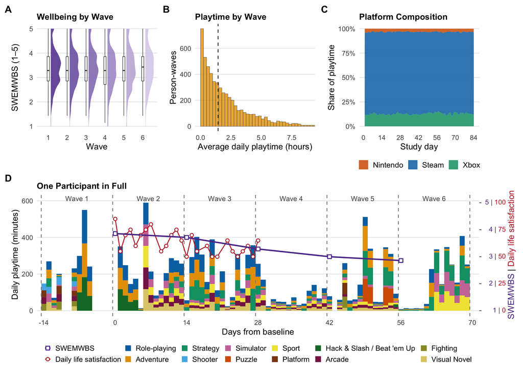

Figure 1: *Distributions, Composition, and Raw Structure of the Study Measures.* (A) SWEMWBS distributions per biweekly wave (density and median box). (B) Average daily hours per person-wave with recorded play (15-minute bins; dashed line: median). (C) Share of recorded playtime per study day by platform, days 1–84. (D) Daily playtime for one participant (ID p5271179686); bar height is genre-matched playtime, segments are its genre composition under proportional multi-membership weighting. Dashed lines mark the six 14-day waves. Two outcomes are overlaid on the right axis: biweekly SWEMWBS (purple open squares, 1–5) at each survey date, and daily life satisfaction from the 30-day diary (red open circles, 0–100).

Figure 1 shows the distributions and structure of the key variables. **Wellbeing.** We assessed wellbeing with the Short Warwick-Edinburgh Mental Well-being Scale (SWEMWBS) (Tennant et al., 2007), a 7-item short form of the WEMWBS covering psychological functioning and subjective wellbeing over the past 2 weeks, with responses on a 5-point Likert scale ranging from “None of the time” to “All of the time.” We scored the scale as the arithmetic mean of the 7 items (range: 1–5). Internal consistency across all analytic person-waves was high (McDonald’s ω<sub>t</sub> = 0.89, Cronbach’s α = 0.89). We define all reported coefficients, the priors, and the preregistered SESOI on this item-mean scale.

**Video game playtime.** Digital trace data from Nintendo, Xbox, and Steam provide session-level records (per-title start and end timestamps), whereas iOS and Android contribute only daily aggregate minutes without game titles. Our analyses of H1 and H2 therefore use Nintendo, Xbox, and Steam (Appendix A, Deviation D4); mobile minutes enter only the first positive control, which compares self-reported with logged playtime, and the preregistered all-platform H1 model in Appendix D (Table 5), so our findings do not speak to mobile play.

**Game genre classification.** We obtained genre labels for Nintendo and Steam games by cross-referencing the game titles in the digital trace data with the Internet Games Database (IGDB), to our knowledge the only database with complete multi-platform metadata coverage that offers an API for programmatic data retrieval; IGDB crowd-sources its labels from a predefined list of genres, and moderators vet each contribution (Appendix B). Because Xbox provided us only with anonymised title identifiers, we could not match Xbox titles to IGDB; instead, we took the genre labels that Xbox supplies for each title through its store and mapped those onto the IGDB taxonomy. We collapsed the 23 distinct raw IGDB genre labels into 14 genre categories (e.g., Strategy subsumes Turn-Based Strategy (TBS), Real-Time Strategy (RTS), Tactical, and MOBA; Puzzle subsumes Card & Board Game and Quiz/Trivia); Appendix B gives the complete mapping, including where it departs from the preregistered collapsing (Deviation D2), and Appendix C the descriptive statistics by genre. We did not consider IGDB “themes” or other metadata fields. Overall, we matched 93.9% of in-study playtime to at least one study genre (Steam 96.2%, Nintendo 93.1%, Xbox 78.8%); unmatched playtime counts towards total playtime but towards no genre.

**Demographics.** Participants self-reported age, gender, ethnicity, country, and employment at baseline. Appendix C tabulates the sample’s characteristics by country.

## From Games to Genre Exposure

Of the 3,651 genre-labelled games in our data (counted separately per platform), 37.6% carry a single genre label, 32.5% two, 21.2% three, and 8.8% four or more, in 323 distinct genre combinations. Figure 2 shows how playtime is distributed over the 40 most-played combinations, which together account for 87% of all genre-matched playtime, and Table 4 in Appendix C lists the ten most-played combinations with their top titles. Because most games combine several genres, the rule that turns a session of play into genre exposure decides what a genre coefficient means.

The preregistration specified *primary attribution*: each game counts towards the genre that IGDB lists first, and a session’s full duration counts towards that genre alone, so a 60-minute session of *Skyrim* (Adventure and RPG) counts as 60 minutes of whichever of its two genres IGDB happens to list first. Genre exposures then stay mutually exclusive and sum to genre-matched playtime, but this is the weakest operationalisation of genre exposure, for reasons that hold before any data are seen: it discards every further label of most games, and it lets the order in which IGDB lists a game’s genres decide which genre the game counts towards. We report the preregistered tests of H2 under this rule first.

After data access and before any results were known, we decided to base the genre models and a second set of joint tests on *full attribution* (Appendix A, Deviation D1), which counts a session’s full duration towards every genre the game carries, so the same *Skyrim* session counts as 60 minutes of Adventure and 60 minutes of RPG. Genre exposures then overlap and no longer sum to total playtime, and a genre coefficient represents the association with an added hour of that genre’s exposure holding total playtime constant, for example, replacing a single-genre RPG session with a dual-genre Adventure/RPG session of the same length. We rejected splitting a session’s playtime across its genres, because each additional label would lower a game’s contribution to every genre it carries (Appendix B).

M4 uses a third representation, *proportional multi-membership weighting*, which describes a wave of play as a genre mix. It divides each genre’s full-attribution hours by the wave’s summed genre exposure, so a wave of 60 minutes of *Skyrim* and 60 minutes of *Final Fantasy XIV Online* (RPG only) weights Adventure at 33.3% and RPG at 66.7%, and it uses these shares as the weights of a multiple-membership structure (Cafri et al., 2015; Fielding & Goldstein, 2006). This weighting shares the drawback for which we rejected splitting playtime, because adding a genre label to a game lowers the shares of the labels it already carries, so none of the rules is free of trade-offs.

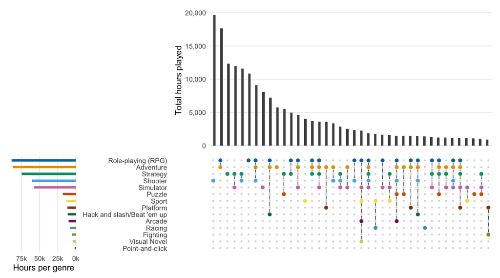

Figure 2: *Genre Co-Occurrence Weighted by Total Playtime.* Top panel: total hours played by games in each genre combination, ordered by playtime. Bottom panel: dot matrix indicating which genres belong to each combination; connected dots denote multi-genre games. Left bars show total hours attributed to each genre, counting a multi-genre game’s full playtime towards each genre exposure.

## Analytic Approach

We conducted all analyses in R (R Core Team, 2025) and wrote the manuscript in Quarto (Allaire et al., 2025). We fitted four Bayesian multilevel models with `brms` (Bürkner, 2017) at the biweekly timescale and refitted each at the daily timescale as an exploratory extension. Sampling ran in CmdStan (version 2.39.0) through `cmdstanr`, with four chains per model and within-chain parallelisation, which affects only computation time. We preregistered two of them: the model of total playtime (M1) tests H1, and the genre model with independently estimated genre coefficients (M2) is the model form of the preregistered joint tests of H2. After seeing the M2 results, we added two exploratory models to describe the size of the genre differences and examine the robustness of the M2 results: M4, built for play that spans several genres, keeps total playtime as the single predictor, as in M1, and lets each wave’s genre mix modify its slope; M3 keeps M2’s predictors but pools the genre coefficients through a common distribution. M4 also yields H1 estimates. All four models use the `brms` default priors, and Appendix F gives their equations and priors in full. We catalogue deviations from the preregistered plan in Appendix A and flag them below where they affect interpretation, and we report the preregistered frequentist analyses in full in Appendix D.

## Smallest Effect Size of Interest and Inference

Establishing the absence of a practically significant effect requires committing in advance to a threshold below which an association is too small to matter, the smallest effect size of interest (SESOI). By practically significant, we mean the smallest change in wellbeing that a player would notice, the minimally important difference (MID). Following previous studies, we set the MID at 0.3 points on the SWEMWBS item-mean scale (1–5; equivalent to 2.1 points on the 7–35 summed scale), converging with anchor- and distribution-based estimates of the Warwick-Edinburgh Mental Well-being Scale (WEMWBS) (Ballou, Sewall, et al., 2024; Maheswaran et al., 2012) and the Positive and Negative Affect Schedule (Anvari & Lakens, 2021).

The SESOI also requires knowing how large a change in playtime is realistically available. US adults average approximately 5 hours of daily leisure time (Sturm & Cohen, 2019), and we take this figure as an upper bound on how much daily play could plausibly rise or fall without displacing other behaviours that arguably impact wellbeing more than play (e.g., sleep); more recent time-use diaries put the figure lower for our age range (Appendix F). Our SESOI is the ratio of the two: 0.3 ÷ 5 = 0.06 points per hour, the same threshold used by Ballou, Sewall, et al. (2024). Below 0.06 points per hour, even shifting an entire 5-hour daily leisure budget into or out of gaming would not change wellbeing noticeably.

We evaluated the two H1 coefficients and each genre’s coefficients against the Region of Practical Equivalence (ROPE), [−0.06, +0.06] (Kruschke, 2018): a 95% credible interval (CI) entirely inside the ROPE indicates a practically null effect, one entirely beyond either bound a practically positive or negative effect, and one straddling either edge an inconclusive result. Throughout, CI denotes a 95% credible interval; the preregistered frequentist tests in Appendix D use 90% confidence intervals, labelled as such. This rule replaces the preregistered H1 decision grid (Deviation D3), which Appendix D applies to the preregistered analyses.

The preregistered joint Wald tests answer H2: run on a maximum-likelihood fit of M2, separately for the 14 within-person (H2a) and the 14 between-person (H2b) genre coefficients and under primary and then full attribution, they show whether at least two genres differ but not by how much. The preregistration fixed no threshold for the size of genre differences, so we describe that size without a verdict, through the spread *s* of the genre effects at each posterior draw (the SD of M2’s 14 coefficients, which their estimation error can inflate; τ<sub>genre</sub> in M3; σ<sub>s</sub> in M4), expressed as the expected number of the 14 genres more than 0.06 from the average genre effect, the share of genre pairs more than 0.06 apart, and the share of the genre-effect distribution outside the ROPE (Vuorre, Kay, et al., 2024). Appendix F gives the formulas and two reference values of *s*, 0.031 and 0.022, which are not thresholds.

## Preregistered Models

### M1: Total Playtime

M1 is the preregistered model for H1: is total playtime across Nintendo, Xbox, and Steam associated with wellbeing? We split each participant’s playtime into a between-person part, their mean across waves, and a within-person part, each wave’s deviation from that mean, and regressed SWEMWBS on both. The model returns two coefficients: $\beta_W$, the association between a wave’s deviation from a person’s usual playtime and that wave’s wellbeing, and $\beta_B$, the association between a person’s habitual playtime and their average wellbeing. We estimated a random intercept for each participant because people differ in baseline wellbeing, and a random slope for within-person playtime because the association need not be identical for everyone (equations and priors in Appendix F).

### M2: Independent Genre Coefficients

M2 is the preregistered model form for H2: a within-person and a between-person coefficient for each of the 14 genres, estimated independently of one another, with a random intercept per participant. Because full-attribution exposures overlap, their sum does not recover total playtime, and M2 contains no separate total-playtime term. It departs from the preregistered specification in two respects: its exposures count every genre label (Deviation D1), and it has the random intercept only, because the preregistered uncorrelated per-participant random slopes for the within-person genre terms gave a singular fit by maximum likelihood, with most of the 14 slope standard deviations estimated at zero, as the preregistration anticipated (equations and priors in Appendix F).

## Exploratory Models

### M4: Multi-Membership

M4 describes each wave by its total playtime and by the genre mix of that playtime, the representation that panel D of Figure 1 shows for days. It inherits M1’s structure, including the overall $\beta_W$ and $\beta_B$, and lets the genre mix modify the playtime slope. Each genre adjusts a wave’s slope in proportion to its share of the wave’s genre exposure, so a wave consisting mostly of Shooter play is governed mostly by the Shooter slope adjustment, and a wave divided between Adventure and RPG draws on both adjustments in proportion. M4 draws the genre adjustments from a common distribution whose standard deviation, σ<sub>s</sub> (within and between persons), describes how much the playtime–wellbeing slope depends on the genres being played (equations, priors, and a parameter-recovery check in Appendix F).

### M3: Hierarchical Prior

M3 keeps M2’s predictors and random intercept but treats the 14 genre-specific coefficients as draws from a common normal distribution, separately for the within-person and between-person dimensions. The centres of these distributions, γ<sub>W</sub> and γ<sub>B</sub>, are the common genre effects around which the genre coefficients vary, and their standard deviations, τ<sub>genre</sub> (τ<sub>within</sub> and τ<sub>between</sub>), measure how widely the genre coefficients spread around them. The shared distribution pulls the estimates for rarely played genres towards the common genre effect, whereas genres with ample data retain estimates close to their independent values, so per-genre intervals from M3 partly reflect the data on the other genres. We estimated the centres only after the results of a zero-centred version were known (Appendix F gives this history, the equations, the priors, and the form in which we sampled the model).

### Daily Timescale

To assess whether our findings hold on a shorter timescale, we conducted an exploratory daily-timescale analysis, whose plan we fixed after the preregistered analyses were complete but before we estimated any daily model. We refitted the model specifications at the daily level (M1-D to M4-D) to the 30-day diary of US participants, with a life-satisfaction item answered on a 0–100 slider as the outcome (Ballou, Földes, Vuorre, et al., 2025) and console and PC playtime from 4:00 a.m. local time up to the diary response as the exposure, and we judged the coefficients against a SESOI of 1 slider point per hour of daily play, constructed in the same way as the preregistered one. We made two changes after the daily results were known: we estimated M3-D’s centres as in M3, and we gave all daily models the `brms` default priors instead of the plan’s rescaled biweekly priors. Appendix D details the window construction, the sample, the SESOI, and four sensitivity refits.

## Missing Data

All missingness in the outcome is wave nonresponse, because every completed survey contains all seven SWEMWBS items. Survey completion declined from 100% at wave 1 to 47% at wave 6, leaving 3,490 of the 10,008 person-waves (34.9%) without an observed SWEMWBS (Ballou, Földes, Vuorre, et al., 2025).

We fitted the models to the observed outcomes, which is valid if outcome missingness is at random given the modelled covariates and random effects, and tested that assumption with two-level multiple imputation of SWEMWBS on the complete participant × wave grid (Appendix D; Deviation D5; results under Robustness). We did not impute playtime, because tracking was continuous and automatic, so within linked platforms an absence of play is recorded absence rather than missing data.

# Results

The analytic sample comprised 1,668 participants with a valid SWEMWBS response in at least one biweekly wave, yielding 6,518 person-wave observations (M = 3.9 of 6 waves per participant; see Missing Data). We measured playtime from linked Nintendo, Xbox, and Steam telemetry; participants played an average of 1.75 hours per day (SD = 2) across the three platforms. Figure rows, legend entries, and table rows are labelled by model and preregistration status.

## Data Quality Controls

Before testing the hypotheses, we ran the three preregistered positive controls, each of which checks that the data reproduce a pattern known to hold. First, self-reported biweekly playtime correlated positively with digital trace playtime (*r* = 0.481, 95% confidence interval [0.459, 0.502], *p* < .001).

Second, session integrity largely held. Xbox contained 0 overlapping sessions, and no Steam session’s recorded playtime exceeded its elapsed wall-clock duration (0 violations). Nintendo retained a small number of overlapping sessions: 717 of 322,662 sessions (0.22%), with a median overlap of 9.8 minutes and accounting for 0.09% of total Nintendo playtime. All overlapping sessions could be traced to concurrent use of multiple consoles linked to one account (e.g., a Switch Lite overlapping an OLED model); given their rarity, we judged them neither a sign of systematic data quality problems nor frequent enough to affect the estimates.

Third, men played more shooter games than women (M = 0.511 vs. 0.327 hrs/day, *t*(1011.5) = 4.2, *p* < .001, Cohen’s *d* = 0.22), meeting the preregistered criterion of a significant difference in the expected direction and consistent with population studies of gendered genre preferences (Rehbein et al., 2016). All three controls passed, and we proceeded to the hypothesis tests.

```r
h1_model <- brm(
  bf(wemwbs ~ total_within + total_between +
       (1 + total_within | pid)),
  data    = analysis_data |> filter(!is.na(wemwbs)),
  # brms default priors (since 2026-10-13; Methods): flat on b,
  # Student-t(3, median(y), 2.5) on the Intercept, half-Student-t(3, 0, 2.5)
  # on sigma and the SDs, LKJ(1) on the correlation.
  family  = gaussian(),
  chains  = 4, iter = 4000, warmup = 2000, seed = 8675309,
  control = list(adapt_delta = 0.95),
  file    = here("models/h1_rewb_model")
)
```

```r
h2_formula <- bf(paste(
  "wemwbs ~",
  paste(c(gh_within, gh_between), collapse = " + "),
  "+ (1 | pid)"
))

h2_model <- brm(
  formula = h2_formula,
  data    = analysis_data |> filter(!is.na(wemwbs)),
  # brms default priors (see h1-fit).
  family  = gaussian(),
  chains  = 4, iter = 4000, warmup = 2000, seed = 8675309,
  control = list(adapt_delta = 0.95),
  file    = here("models/h2_genre_model")
)
```

```r
# M3: same genre-exposure structure as M2, but the 14 within-person and the 14
# between-person genre coefficients are drawn from common normal
# distributions: beta_W,g ~ Normal(gamma_W, tau_within) and
# beta_B,g ~ Normal(gamma_B, tau_between), with the centres gamma and the
# spreads tau estimated. No total_within/total_between: genre exposure columns
# are non-exclusive (full attribution), so partialing out total playtime would
# leave only multi-genre inflation artifacts.
#
# Non-centred form (since 2026-10-14). Writing beta_g = gamma + r_g with
# r_g ~ Normal(0, tau) gives sum_g x_g beta_g = gamma * sum_g x_g +
# sum_g x_g r_g: a fixed slope on the summed exposure plus a multi-membership
# intercept over the 14 genres whose weights are the exposures. brms samples
# group-level effects as r = tau * z with z ~ Normal(0, 1), so this is the
# non-centred parameterisation of the same model (same likelihood; same flat
# prior on gamma and half-Student-t(3, 0, S) prior on tau). Every parameter
# keeps its brms default, so no prior and no stanvars are set: gamma_W =
# b_sum_within and gamma_B = b_sum_between are flat; tau_within and
# tau_between are the SDs of the two mm intercepts (default sd prior,
# half-Student-t(3, 0, S), S = max(2.5, mad(y)) = 2.5 for SWEMWBS). The only
# difference from the centred fit concerns the default Intercept prior: brms
# centres the population-level predictors before placing the default
# Intercept prior, so that prior now sits on the expected outcome at the mean
# summed exposures with every genre deviation at zero (a Student-t with scale
# 2.5, wide relative to any genre contribution).
# scale = FALSE is essential: the weights are exposures in hours/day (the
# within-person ones signed), not shares, and must enter unrescaled.
# Per-genre coefficients for every downstream use: beta_g = gamma + r_g,
# computed draw-wise (h2_hier_nc below), as for M4's genre slopes.
# History: models/h2_hier_model_v2 had the centres fixed at zero (stanvars);
# models/h2_hier_model_v3 (2026-10-13) estimated the centres, but in the
# centred form (stanvars + 28 structural normal(mu, tau) priors) it had 68
# divergent transitions in 16,000 draws at adapt_delta = 0.999 (Neal's funnel
# as tau approaches zero; archived fit kept for comparison);
# models/h2_hier_model_v4 is this non-centred multi-membership form
# (2026-10-14). New file names keep an older fit from being reloaded through
# brms `file =` (scripts/refit_v126.sh, now scripts/refit_v130.sh).
h2_hier_data <- analysis_data |> filter(!is.na(wemwbs))
hier_genres  <- sub("^gh_", "", gh_vars)  # 14 genre slugs, alphabetical
stopifnot(length(hier_genres) == 14, !anyDuplicated(hier_genres),
          identical(gh_within,  paste0(gh_vars, "_within")),
          identical(gh_between, paste0(gh_vars, "_between")))
# 2 x 14 constant genre-label columns, one per membership slot; level k of
# the k-th column is the k-th genre, so each mm term has exactly 14 levels.
hier_gw_cols <- paste0("gW_", seq_along(hier_genres))
hier_gb_cols <- paste0("gB_", seq_along(hier_genres))
for (k in seq_along(hier_genres)) {
  h2_hier_data[[hier_gw_cols[k]]] <- factor(hier_genres[k], levels = hier_genres)
  h2_hier_data[[hier_gb_cols[k]]] <- factor(hier_genres[k], levels = hier_genres)
}
h2_hier_data$sum_within  <- rowSums(h2_hier_data[gh_within])
h2_hier_data$sum_between <- rowSums(h2_hier_data[gh_between])

hier_mm_term <- function(g_cols, x_cols) {
  sprintf("(1 | mm(%s, weights = cbind(%s), scale = FALSE))",
          paste(g_cols, collapse = ", "), paste(x_cols, collapse = ", "))
}
h2_hier_formula <- bf(paste(
  "wemwbs ~ sum_within + sum_between + (1 | pid) +",
  hier_mm_term(hier_gw_cols, gh_within), "+",
  hier_mm_term(hier_gb_cols, gh_between)
))
# brms names an mm group "mm" followed by its member variables.
h2_hier_group_w <- paste0("mm", paste(hier_gw_cols, collapse = ""))
h2_hier_group_b <- paste0("mm", paste(hier_gb_cols, collapse = ""))

# Prior check: every prior is the brms default. The Methods state S = 2.5 for
# every SD (tau_within and tau_between included) and an intercept location
# equal to the rounded sample median (txt_wemwbs_median, chunk txt-priors,
# computed from the same observations); all must match what brms uses.
h2_hier_default_prior <- brms::default_prior(h2_hier_formula, data = h2_hier_data,
                                             family = gaussian())
stopifnot(setequal(unique(h2_hier_default_prior$group[grepl("^mm", h2_hier_default_prior$group)]),
                   c(h2_hier_group_w, h2_hier_group_b)))
sd_default_string <- with(h2_hier_default_prior,
                          prior[class == "sd" & group == "" & coef == ""])
stopifnot(length(sd_default_string) == 1,
          grepl("^student_t\\(3, 0, [0-9.]+\\)$", sd_default_string))
tau_prior_scale <- as.numeric(sub("^student_t\\(3, 0, ([0-9.]+)\\)$", "\\1",
                                  sd_default_string))
intercept_default_string <- with(h2_hier_default_prior, prior[class == "Intercept"])
stopifnot(tau_prior_scale == 2.5,
          txt_wemwbs_median == round(median(h2_hier_data$wemwbs), 1),
          intercept_default_string ==
            sprintf("student_t(3, %s, %s)", round(median(h2_hier_data$wemwbs), 1),
                    tau_prior_scale))

h2_hier_model <- brm(
  formula  = h2_hier_formula,
  data     = h2_hier_data,
  # brms default priors (see above); no prior, no stanvars.
  family   = gaussian(),
  chains   = 4, iter = 8000, warmup = 4000, seed = 2025,
  control  = list(adapt_delta = 0.999, max_treedepth = 15),
  file     = here("models/h2_hier_model_v4")
)

# Draw-wise M3 quantities from a non-centred fit (also used for M3-D in chunk
# daily-fits): gamma = b_sum_*, tau = sd_<mm group>__Intercept, and the
# per-genre coefficients beta_g = gamma + r_<mm group>[g,Intercept]. The mm
# group names are found from the fit's variables (sd_mmgW_... / sd_mmgB_...);
# exactly 14 r_ columns per term must exist, in the order of `genres`.
hier_nc_draws <- function(fit, genres, group_w = NULL, group_b = NULL) {
  vars <- brms::variables(fit)
  find_group <- function(prefix) {
    hit <- vars[grepl(sprintf("^sd_mm%s1%s2.*__Intercept$", prefix, prefix), vars)]
    stopifnot(length(hit) == 1)
    sub("__Intercept$", "", sub("^sd_", "", hit))
  }
  gw <- find_group("gW_")
  gb <- find_group("gB_")
  if (!is.null(group_w)) stopifnot(identical(gw, group_w))
  if (!is.null(group_b)) stopifnot(identical(gb, group_b))
  r_cols <- function(g) {
    cols <- vars[startsWith(vars, paste0("r_", g, "["))]
    lev  <- sub(",Intercept\\]$", "", sub(paste0("r_", g, "["), "", cols, fixed = TRUE))
    stopifnot(length(cols) == 14, identical(lev, genres),
              all(endsWith(cols, ",Intercept]")))
    cols
  }
  rw <- r_cols(gw)
  rb <- r_cols(gb)
  need <- c("b_sum_within", "b_sum_between",
            paste0("sd_", gw, "__Intercept"), paste0("sd_", gb, "__Intercept"), rw, rb)
  stopifnot(all(need %in% vars))
  dr <- posterior::as_draws_df(fit, variable = need)
  gamma_w <- dr$b_sum_within
  gamma_b <- dr$b_sum_between
  beta_w  <- gamma_w + sapply(rw, function(v) dr[[v]])  # draws x 14
  beta_b  <- gamma_b + sapply(rb, function(v) dr[[v]])
  colnames(beta_w) <- colnames(beta_b) <- genres
  list(gamma_w = gamma_w, gamma_b = gamma_b,
       tau_w = dr[[paste0("sd_", gw, "__Intercept")]],
       tau_b = dr[[paste0("sd_", gb, "__Intercept")]],
       beta_w = beta_w, beta_b = beta_b, group_w = gw, group_b = gb)
}
h2_hier_nc <- hier_nc_draws(h2_hier_model, hier_genres,
                            group_w = h2_hier_group_w, group_b = h2_hier_group_b)
```

```r
h2_mm_model <- brm(
  formula = h2_mm_formula,
  data    = mm_data |> filter(!is.na(wemwbs)),
  # brms default priors (see mm-formula-setup).
  family  = gaussian(),
  chains  = 4,
  iter    = 8000,
  warmup  = 4000,
  seed    = 8675309,
  control = list(adapt_delta = 0.999, max_treedepth = 15),
  file    = here("models/h2_mm_model_full")
)
```

## Total Playtime (H1)

H1 predicted that total playtime is not meaningfully associated with wellbeing, whether a person plays more or less than usual in a given wave (H1a) or habitually plays more or less than other people (H1b). We judged the two coefficients of the preregistered model, M1, against the ROPE of ±0.06 points per hour/day, with Bayesian estimation in place of the preregistered frequentist equivalence test (Deviation D3). Figure 3 shows the posterior distributions, and Appendix E (Table 10) tabulates all hypothesis tests.

### Preregistered Model (M1)

Within persons (H1a), the posterior mean was 0.004 SWEMWBS item-mean points per hour/day (95% CI: [-0.007, 0.015]), with >99.9% of the posterior draws inside the ROPE. In waves in which a participant played more than their own average, wellbeing did not differ by a practically meaningful amount.

Between persons (H1b), the posterior mean was -0.015 (95% CI: [-0.034, 0.003]), with >99.9% of the posterior draws inside the ROPE. The estimate leaned negative, with a credible interval that reached zero, but its magnitude was far below the SESOI: a 2 hour/day difference in habitual playtime corresponded to -0.031 points on the 1–5 scale, about 0.8% of the 4-point range. Both components of H1 were supported under the ROPE rule (Deviation D3) and under the preregistered 90% CI grid (Appendix D), which classified each coefficient as showing no practically significant association.

M1’s random slope estimates how much the within-person association varies between participants. The SD of the person-specific associations was 0.029 (95% CI: [0.003, 0.058]), and 1.8% of its posterior lay above the SESOI. Under the model’s normal random-slope assumption, this spread combined with the average association implied that the within-person association exceeded the SESOI, in either direction, for about 8.1% of participants.

### Exploratory Model (M4)

M4’s fixed effects are also H1 quantities: the average within-person and between-person associations of total playtime, estimated without assuming that the association is the same for every genre. Within persons, β<sub>W</sub> = 0.008 (95% CI: [-0.019, 0.041]), with 99.6% of the posterior draws inside the ROPE; between persons, β<sub>B</sub> = -0.013 (95% CI: [-0.035, 0.012]), with >99.9% of the draws inside (Figure 3). Allowing the association to depend on which genres were played left the total-playtime association unchanged.

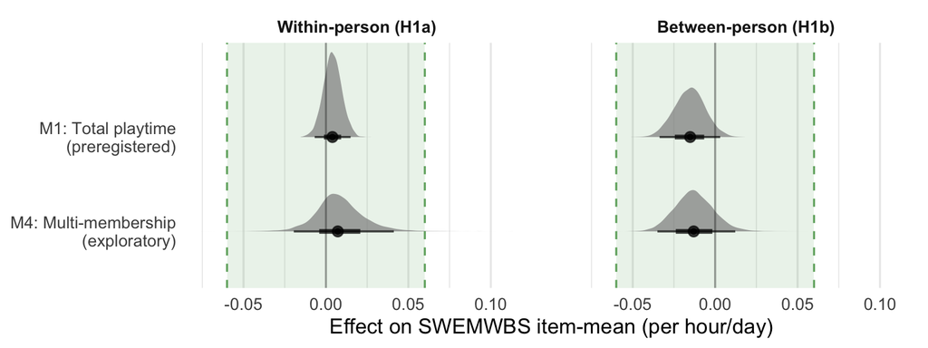

Figure 3: *Posterior Distributions for Total Playtime Effects (H1).* M1 (top row) is the preregistered total-playtime model; M4 (bottom row) is the exploratory multi-membership model, which keeps total playtime as its predictor and lets genre composition modify the slope. M2 and M3 have no separate total-playtime predictor and are excluded. Green band: ROPE (±0.06). Thick: 66% credible interval; thin: 95% CI.

## Genre Differences (H2)

Our second hypothesis was that genres differ in how playtime relates to wellbeing within persons (H2a) and between persons (H2b). The exploratory models M4 and M3 describe how large the genre differences are. Figure 4 and Figure 5 show the model results.

### Preregistered Analysis (M2)

We fitted a frequentist version of M2 by maximum likelihood, with the same fixed effects and random intercept, and tested whether its 14 within-person and its 14 between-person genre coefficients were equal; rejecting equality means that at least two genres differ, without saying which or by how much. Under the preregistered primary attribution, in which each game counts towards the first genre IGDB lists for it, neither test rejected equality, within persons (χ²(13) = 16.6, *p* = 0.216) or between persons (χ²(13) = 15.4, *p* = 0.284). Under the preregistered rule, neither H2a nor H2b was supported.

For the reasons set out in the Methods, primary attribution is the weakest of the three operationalisations. Under full attribution, which we adopted after data access and before any results were known (Deviation D1), the within-person test rejected equality (χ²(13) = 24.8, *p* = 0.025) and the between-person test did not (χ²(13) = 14.9, *p* = 0.315). Under this deviation, H2a was supported and H2b was not, so the support for H2a depends on the attribution rule, and the within-person rejection did not hold under multiple imputation (Robustness). Appendix D reports all preregistered tests (Table 5).

Under full attribution, M2’s per-genre estimates clustered near zero (Figure 5, blue circles): 8 of the 14 within-person credible intervals fell entirely inside the ROPE, and the remainder straddled a boundary rather than excluding it. Estimated independently, the coefficients of rarely played genres were imprecise, with the widest within-person interval (Point-and-Click) about 5 times wider than the narrowest, so the SD of the 14 estimates can overstate how much the genres differ (Appendix E). Between persons the intervals were wider still, with 2 of the 14 entirely inside the ROPE.

### Exploratory Models (M4 and M3)

M4 treats each wave as a genre mix that adjusts a single playtime slope, so its spread describes how much the playtime–wellbeing slope depends on the genres being played. Within persons (H2a), $\sigma_{s,\text{within}}$ = 0.038 (95% CI: [0.004, 0.091]; Figure 4, middle row), which implied that an expected 2.0 of the 14 genres deviated from the overall playtime slope by more than 0.06 and that 24.8% of genre pairs differed by more than 0.06. The estimate was imprecise: spreads up to the upper credible bound of 0.091 points per hour/day remained plausible, so this model cannot exclude differences confined to a few genres. Between persons (H2b), $\sigma_{s,\text{between}}$ = 0.019 (95% CI: [0.002, 0.047]; an expected 0.35 genres and 6.9% of pairs). With the overall slope added back, M4’s per-genre estimates spanned -0.021 to 0.038 within persons and -0.034 to -0.003 between persons (Figure 5, purple diamonds).

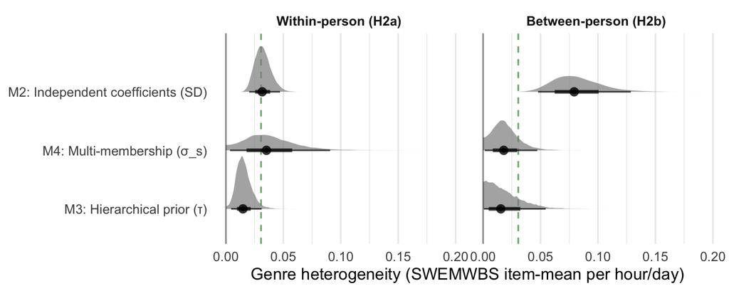

Figure 4: *Genre Heterogeneity Under Three Model Specifications (H2).* Left: within-person (H2a); right: between-person (H2b). M2 (top row) is the preregistered model (SD of its 14 independently estimated coefficients, inflated by their estimation noise); M4 (middle row) and M3 (bottom row) are exploratory (σ<sub>s</sub> and τ, model-estimated spreads). Dashed line: reference value of 0.031, the spread at which 95% of genre effects would lie within 0.06 of the average genre effect; the corresponding value for 95% of genre pairs differing by less than 0.06 is 0.022. Both are reference points, not decision criteria (Appendix F, Spread Descriptors). Thick: 66% credible interval; thin: 95% CI.

M3 pools the 14 full-attribution coefficients through a common distribution, which shrinks the noisier estimates towards the common genre effect and reduces the impact of noise and of multiple comparisons (Gelman et al., 2012), and it estimated the within-person spread more precisely than M4: τ<sub>within</sub> = 0.016 (95% CI: [0.005, 0.031]; Figure 4, bottom row), which implied that an expected 0.08 of the 14 genres lay more than 0.06 from the common genre effect and that 2.6% of genre pairs differed by more than 0.06. The prior on τ places 0.9% of its mass below the reference value of 0.031, against 97.2% of the posterior for τ<sub>within</sub>, so the concentration of τ<sub>within</sub> at small values came from the data rather than the prior. Between persons (H2b), τ<sub>between</sub> = 0.019 (95% CI: [0.001, 0.054]; an expected 0.48 genres and 7.9% of pairs). The common genre effects were γ<sub>W</sub> = 0.003 within persons (95% CI: [-0.008, 0.015]) and γ<sub>B</sub> = -0.008 between persons (95% CI: [-0.026, 0.011]).

With the coefficients pooled, every genre’s association lay close to zero (Figure 5, orange squares): 14 of the 14 within-person credible intervals fell entirely inside the ROPE, as did 10 of the 14 wider between-person intervals. Whether the associations are practically null in every genre depends on where the genre effects are centred as well as on their spread, so we also computed, at each posterior draw, the share of M3’s genre-effect distribution lying outside the ROPE: 0.7% within persons (95% CI: [0%, 7%]) and 4.2% between persons (95% CI: [0%, 30.7%]). Within persons, this share was smaller than under M2 or M4 (Appendix E).

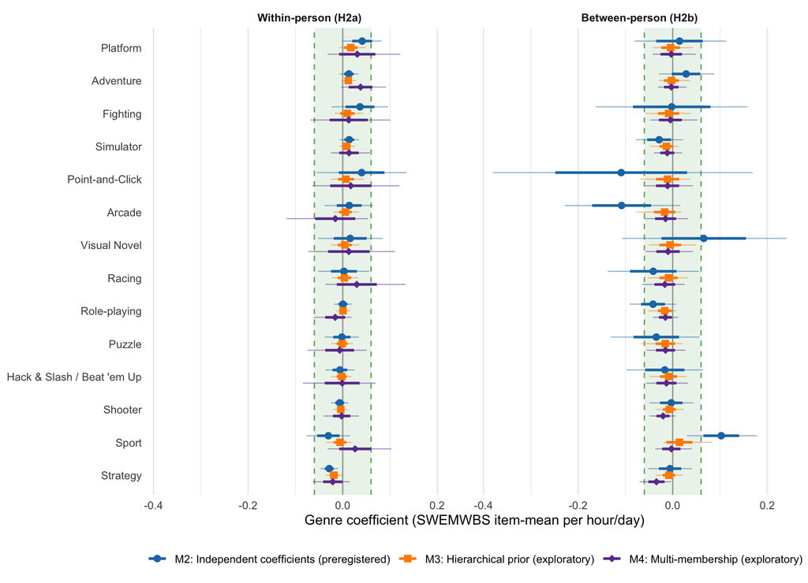

Figure 5: *Per-Genre Exposure Coefficients Under Three Model Specifications (H2).* Left: within-person (H2a); right: between-person (H2b). Each genre row shows M2 (blue circle; preregistered model, no pooling), M3 (orange square; exploratory, hierarchical prior), and M4 (purple diamond; exploratory, multi-membership). The M2 series corresponds to the preregistered caterpillar plot, under full attribution (Deviation D1) and Bayesian estimation (Deviation D3). Genres ordered by the M3 within-person estimate. Green band: ROPE (±0.06). Thick bars: ±1 posterior SD; thin bars: 95% CI.

In sum, under the preregistered primary attribution the joint tests did not detect genre differences. Under full attribution (Deviation D1), the within-person test detected differences, a result that did not hold under imputation; M3 placed every genre’s association close to zero, and M4, which estimated the spread less precisely, could not rule out larger differences in a few genres. Genre terms did not improve out-of-sample prediction over total playtime alone (Appendix D), and the wide intervals for rarely played genres ruled out confident inference about any single genre. Appendix E (Table 10) tabulates the joint tests, the spread estimates and their descriptors, and the convergence diagnostics; full posterior summaries for all four models are in the supplementary materials.

## Daily Timescale (Exploratory)

The daily-level analyses (M1-D to M4-D) were not preregistered, and every estimate in this section is exploratory. Within persons, the association between same-day playtime and life satisfaction was positive, at β = 0.17 points per additional hour in the standalone total-playtime model (M1-D; 95% CI [0, 0.34]), with the lower credible bound at zero and >99.9% of the posterior draws inside the ROPE; the interval widened past zero under two of the three sensitivity refits that re-estimate it. Between persons, participants who habitually played more reported slightly lower daily life satisfaction (M1-D: β = -0.4 points per habitual daily hour, 95% CI [-1.15, 0.29]; 94.7% of the posterior inside the ROPE). Under the hierarchical prior, the within-person genre spread was τ<sub>within</sub> = 0.22 (95% CI [0.01, 0.57]), an expected 0.10 of the 14 genres more than one slider point per hour from the common genre effect. Appendix D reports the remaining daily estimates (Figure 7), and Appendix E tabulates them (Table 11).

## Robustness

Neither of the two sensitivity analyses changed the H1 conclusion. Adjusting for age, gender, and ethnicity shifted the H1 coefficients by less than 0.01 points and changed no ROPE verdict (Appendix D, Table 6). Refitting on multiply imputed data (m = 100) left neither H1 coefficient practically significant under the preregistered 90% CI grid, but, unlike the complete-case analysis, the pooled tests rejected genre-coefficient equality in neither dimension, so the within-person rejection under full attribution did not hold under imputation (Appendix D, Table 8). The preregistered frequentist analyses likewise showed no practically significant H1 coefficient with mobile play included (Appendix D, Table 5).

# Discussion

When previous work has reported that time spent gaming carries no meaningful association with wellbeing, a common objection is that it must surely depend on the type of game: a relaxing puzzle game and a competitive shooter should not plausibly have the same effect on the person playing them. Video game heterogeneity is the standing explanation for why aggregate playtime nulls should not be taken at face value: playtime is a poorly specified exposure whose associations average over distinct causal contrasts (Ballou, Hakman, et al., 2025; Magnusson et al., 2024), and a null total association can in principle be produced by heterogeneous true effects that offset in aggregate (Yarkoni, 2022). Genre is the most widely used name for those contrasts (Starosta et al., 2024), which makes it the natural first place to look.

Prior genre research has looked there under at least one of three measurement limitations, each of which this study addresses. First, genre labels have typically been assigned by participants or researchers, inconsistently across studies, and nearly all taxonomies force each game into a single genre despite modern games being multi-genre by design (King et al., 2019; Starosta et al., 2024); we applied one crowd-sourced taxonomy to every title and kept each game’s multiple labels. Second, playtime has often been self-reported, although self-reported and logged media use correlate only moderately, with a meta-analytic estimate of *r* = 0.38 (Parry et al., 2021); in our data the correlation was *r* = 0.481, so self-reports shared only 23% of their variance with the telemetry we used instead. Third, studies often cover a single game or a handful of titles (Brühlmann et al., 2020; Johannes et al., 2021; Larrieu et al., 2023), leaving genre contrasts to be assembled across studies that measured play and genre incommensurably, often years apart in a medium whose genre labels drift (Cohen, 1986; Vargas-Iglesias, 2020); we estimated all 14 genres jointly in one sample.

In short, total playtime was not meaningfully associated with wellbeing within or between persons, and whether genres differed depended on how genre was measured. Under the preregistered primary attribution, the joint tests detected no differences; under full attribution, they detected within-person differences that did not hold under imputation; and the exploratory hierarchical model placed every genre’s association close to zero.

## The Playtime–Wellbeing Association Is Practically Equivalent to Zero

Within persons, wellbeing barely changed when participants played more than their own average, consistent with previous digital trace studies (Ballou, Sewall, et al., 2024; Ballou, Vuorre, et al., 2025; Larrieu et al., 2023). Even if these associations were causal, wellbeing would shift by one minimally important difference only after roughly 75 additional hours of play per day at the within-person point estimate, and after 20 hours at the credible bound most favourable to an association, more extreme than the 10 additional daily hours that Vuorre et al. (2022) derived from game-level telemetry. Between participants, the habitual difference needed to reach the same threshold lies between 9 and 19 hours of daily play. Both requirements exceed the roughly five hours of daily leisure available to US adults (Sturm & Cohen, 2019), and changes of this order do not occur in practice: only 113 of the 1,442 participants observed across adjacent waves ever changed their average daily play by 4 or more hours between waves. An association that no achievable change in play can reach is, in practice, indistinguishable from none.

Participants who habitually played more reported slightly lower average wellbeing, yet the same participants’ wellbeing did not fall in waves when they played more than usual. This within-null, between-negative pattern recurs across observational media research and most plausibly reflects selection, with people of lower baseline wellbeing spending more time in games rather than games lowering wellbeing (Ballou, Vuorre, et al., 2025; Kievit et al., 2013; Robinson, 1950; Rohrer & Murayama, 2023), although a cumulative effect accruing over years would look the same at these timescales (cf. Vuorre et al., 2022). Whichever explanation holds, the difference is too small to matter, so public claims about gamers’ mental health are, in effect, reports about who plays rather than about what playing does. Causal estimates from Japanese console lotteries point the other way, at 0.2 to 0.5 standard deviations per additional daily hour (Egami et al., 2024; Egami et al., 2026), but they concern acquiring a new console and self-reported play rather than logged deviations from usual playtime among people who already play, two versions of the same nominal exposure (Magnusson et al., 2024).

## Genre Differences Depend on How Genre Is Measured, and Every Genre’s Association Lies Near Zero

We expected genres to differ in how playtime relates to wellbeing. The preregistered rule is the weakest way to ask this question (Methods), so its null result alone says little; but the only evidence of genre differences, from full attribution, did not hold under multiple imputation, which counsels against reading it as firm evidence that genres differ. The within-person differences detected under full attribution lie between genre effects that are all close to zero. Under the hierarchical prior, the 14 within-person genre estimates span only -0.019 to +0.017, with no estimate more than a third of the SESOI from zero, and the most-played genres by total playtime (Role-playing, Adventure, Strategy, Shooter; see Figure 2) sit inside this same narrow band. The multi-membership model is less precise: at the upper credible bound of its spread, an expected 7.1 of the 14 genres deviate from the average slope by more than 0.06, so differences confined to a few genres cannot be excluded. Inference about single genres is limited as well, because the credible intervals for rarely played genres remain wide. Any defence of playtime nulls that appeals to the heterogeneous nature of video games would therefore do better to look to partitions finer than genre.

Near-zero genre associations with general wellbeing do not contradict the genre differences reported before, because those concern other outcomes and other designs: gaming disorder symptoms, where MMORPG, shooter, and strategy play stand out in cross-sectional surveys of self-reported genre preference (Elliott et al., 2012; King et al., 2019; Na et al., 2017; Rehbein et al., 2021), and player experience, where genres differ in immersion, autonomy, and frustration (Hazel et al., 2022; Johnson et al., 2015). Genre also explains little of why people play: among more than 14,000 highly engaged players, correlations between six gaming motives and genre preference ranged from −0.25 to 0.20 (Király et al., 2022). Our estimand, the association between logged exposure to a genre and general wellbeing, is a different one.

To our knowledge, this is the first application in media psychology of the multi-membership model class, developed originally for educational data in which students attend multiple schools (Cafri et al., 2015; Fielding & Goldstein, 2006). Treating genres as overlapping memberships rather than exclusive bins transfers beyond games: any media effects question with overlapping content labels, such as streaming titles with several genre tags or news diets spanning outlets, has the same structure, and our code is freely available for such applications.

## A Susceptible Minority and a Shorter Timescale

Still, a null average could conceal a minority for whom play, in total or in specific genres, genuinely matters (cf. Karhulahti et al., 2025). For total playtime, M1’s random slope implied that an estimated 8.1% of participants (95% CI [0%, 30.2%]) have a true within-person association beyond the SESOI in either direction (Results). A susceptible minority is therefore entirely compatible with our results; what the data constrain is that such susceptibility is neither common nor, for most of the distribution, large at these timescales. Person-specific slope estimates are heavily shrunk towards the mean given the number of waves per participant, so the model quantifies how heavy the tails are without being able to identify which individuals occupy them.

The wellbeing effects of play might also surface and dissipate faster than a biweekly retrospective survey can register. The exploratory daily analysis, which shortened the window from fourteen days to one, reproduced the within-person total-playtime conclusion, whereas between persons the credible interval reached the daily SESOI. The same-day point estimate was positive, about a quarter larger than its biweekly counterpart in within-person standard-deviation units (0.014 versus 0.011 s<sub>w</sub> per hour), a direction consistent with the session-level affective uplift reported among *PowerWash Simulator* players (Vuorre, Ballou, et al., 2024), though fragile across the sensitivity refits. Shifting daily life satisfaction by one minimally important difference (5 points on the 0–100 slider) would nevertheless require 29 additional hours of same-day play, so moving the measurement closer in time does not, on its own, recover a meaningful effect.

## Are All Games the Same?

The question this study set out to answer rests on an undisputed fact, that games differ psychologically, and the intuition persists, although current genre labels appear not to operationalise those differences effectively for wellbeing. Game scholars have argued for decades that genre labels are conventions of marketing and library organisation rather than coherent descriptions of play: they conflate gameplay style, purpose, and mood in a single word (Lee et al., 2014), fail elementary classificatory tests (Clarke et al., 2017), and drift as the medium evolves (Cohen, 1986; Vargas-Iglesias, 2020). Even the researchers who documented attentional benefits of action games now regard genre labels as poor proxies for the mechanics involved (Bavelier & Green, 2019; Nguyen & Bavelier, 2023), and games within one genre can differ sharply in structure, as the shooters *Call of Duty* and *Halo* do (Saini & Hodgins, 2023). The pathways plausibly connecting play to wellbeing seem to operate at levels that genre labels cannot index (Ballou, Hakman, et al., 2025): need satisfaction depends on autonomy-supportive design features (Ballou et al., 2023; Peng et al., 2012), social capital on co-play relationships (Depping et al., 2018; Vella et al., 2015), and affect regulation on the match between gameplay and current emotional state (Kosa et al., 2020).

Other aspects of gameplay besides genre are likely more meaningful for wellbeing. Structural characteristics (e.g., avatar customisability) are one, for which dedicated taxonomies now exist (e.g., Saini & Hodgins, 2023). In-game behaviour is another: within a single game, variation in how people play is linked to meaningful wellbeing differences even when genre is held constant (e.g., Hakman et al., 2026). How players fit gaming into their lives is a third: among casual Nintendo players, self-rated gaming life fit predicted wellbeing an order of magnitude more strongly than any playtime measure (Ballou, Vuorre, et al., 2025). Community-assigned tags that describe mechanics, themes, and social structure may offer a practical middle ground between genre labels and title-level coding (Li, 2020; Starosta et al., 2024). Monetisation, which our data could not test, may matter as well: free-to-play models and loot boxes, argued to harm players (Rehbein et al., 2021; Saini & Hodgins, 2023), need not be spread evenly across genres, so a genre contrast may partly carry a monetisation contrast; in one clinical sample, the two were entangled closely enough that the authors proposed monetisation model as the more tractable partition (André et al., 2024).

## Limitations

Several limitations constrain these conclusions and point at the work that should come next. First, the design is observational. The within-person decomposition removes stable confounds but not time-varying ones, and players themselves name illness, grief, work pressure, and caretaking as events that move both play and wellbeing, sometimes in opposite directions (Ballou, Földes, Hakman, et al., 2025); our causal statements are correspondingly guarded (Rohrer & Murayama, 2023). Second, the SWEMWBS is a global instrument assessed over a two-week recall window. Gaming sits alongside factors like sleep, work, and social life for wellbeing variance, and domain-specific outcomes (affect, sleep, connectedness) could show associations a global measure averages away. The exploratory daily analysis takes one step down this temporal hierarchy, but future work should consider pairing session-level telemetry with momentary assessments and using time-use data to partial gaming from competing activities. Third, coverage is imperfect: some participants used additional platforms whose telemetry we could not capture, Nintendo telemetry covers first-party titles only (Ballou, Földes, Vuorre, et al., 2025), the main and genre analyses excluded mobile play (Measures), and in-study minutes are dominated by Steam (84%, versus 12.5% Xbox and 3.5% Nintendo), so the genre findings are predominantly findings about PC play by UK and US adults. Fourth, participants were adults aged 18 to 40 at screening, so our conclusions say nothing about children or adolescents, for whom both play patterns and susceptibility may differ. Nor do they extend to disordered play in clinical or at-risk populations, where genre-linked structural characteristics remain plausibly relevant (André et al., 2024; Rehbein et al., 2021). Stated as constraints on generality (Simons et al., 2017), our conclusions apply to adults aged 18 to 40 in the UK and US, to console and PC play recorded during the Open Play study period, and to the IGDB genre taxonomy; we have no reason to believe they depend on other characteristics of the sample, but they have not been tested beyond it.

## Data and Code Availability

The Open Play dataset (v1.3.0) is openly available on Zenodo at https://zenodo.org/records/23419571, released under a CC0 licence with a supplemental no-reidentification clause (Ballou, Földes, Vuorre, et al., 2025; Ballou et al., 2026). All analysis code is available at https://github.com/Thomhak/open-play-genres. Preregistration materials for the Stage 1 programmatic Registered Report are available at https://osf.io/mvngt/.

## Funding

This research was supported by the UK Economic and Social Research Council (ES/W012626/1 and ES/Y010736/1). AKP was supported by the Huo Family Foundation.

## Conflicts of Interest

The authors declare no competing financial, intellectual, or institutional interests relevant to this research. The disclosures below are provided in the interest of full transparency.

All members of the research team have worked on scientific projects funded by government and charitable grants that used data from tech companies provided under a data-sharing agreement. No authors have received funding or compensation from the tech companies or other industries connected to the work presented here. Data-sharing partners had no role in the design, analysis, or publication of results.

MV has provided in-kind consultations and served as a nonpaid panel member for Meta and K-Games. AKP has served in advisory or expert roles for the Sync Digital Wellbeing Program (2022–2024), the Google Expert Advisory on Youth and Technology (2025), the OpenAI Expert Council on Well-Being and AI (2025), and UK Department for Science, Innovation and Technology–funded research on children’s smartphone and social media use (University of Cambridge, 2025). He is a member of the UK Department for Culture, Media & Sport College of Experts. Any industry fees are directly donated to charity, and his research is conducted in accordance with University of Oxford academic integrity policies.

# References

Allaire, J. J., Teague, C., Scheidegger, C., Xie, Y., Dervieux, C., & Woodhull, G. (2025). *Quarto*. https://doi.org/10.5281/zenodo.5960048

André, F., Bore, P., Toresson, T., Andersson, M., & Claesdotter-Knutsson, E. (2024). The relationship between game genre, monetization strategy and symptoms of gaming disorder in a clinical sample of adolescents. *Upsala Journal of Medical Sciences*, *129*, e10386–e10386. https://doi.org/10.48101/ujms.v129.10386

Anguera, J. A., Boccanfuso, J., Rintoul, J. L., Al-Hashimi, O., Faraji, F., Janowich, J., Kong, E., Larraburo, Y., Rolle, C., Johnston, E., & Gazzaley, A. (2013). Video game training enhances cognitive control in older adults. *Nature*, *501*, 97–101. https://doi.org/10.1038/nature12486

Anvari, F., & Lakens, D. (2021). Using anchor-based methods to determine the smallest effect size of interest. *Journal of Experimental Social Psychology*, *96*, 104159. https://doi.org/10.1016/j.jesp.2021.104159

Ballou, N., Deterding, S., Iacovides, I., & Heljakka, K. (2023). “I had so many decisions to make and that felt empowering”: Player perceptions of autonomy, competence, and relatedness satisfaction and frustration in video games. *Proc. ACM Hum.-Comput. Interact.*, *7*(CHI PLAY). https://doi.org/10.1145/3611053

Ballou, N., Földes, A. T., Hakman, T., & Przybylski, A. K. (2025). *Ill Health and Grief Fuel Gaming, while Lethargy Slows It: Playtime–Wellbeing Confounds from the Player Perspective*. OSF. https://doi.org/10.31234/osf.io/2v73d_v3

Ballou, N., Földes, A. T., Hakman, T., Vuorre, M., Magnusson, K., & Przybylski, A. K. (2024). *Psychological Wellbeing, Sleep, and Video Gaming: Analyses of Comprehensive Digital Traces*. https://doi.org/10.17605/OSF.IO/MVNGT

Ballou, N., Földes, T. A., Vuorre, M., Hakman, T., Magnusson, K., & Przybylski, A. K. (2026). *Open Play: A longitudinal dataset of multi-platform video game digital trace data and psychological measures* (Version v1.3.0) [Dataset]. Zenodo. https://doi.org/10.5281/zenodo.23419571

Ballou, N., Földes, T. A., Vuorre, M., Hakman, T., Magnusson, K., & Przybylski, A. K. (2025). *Open Play: A longitudinal dataset of multi-platform video game digital trace data and psychological measures* (nz96c_v1). PsyArXiv. https://doi.org/10.31234/osf.io/nz96c_v1

Ballou, N., Hakman, T., Vuorre, M., Magnusson, K., & Przybylski, A. K. (2025). How Do Video Games Affect Mental Health? A Narrative Review of 13 Proposed Mechanisms. *Technology, Mind, and Behavior*, *6*(2). https://doi.org/10.1037/tmb0000152

Ballou, N., Sewall, C. J. R., Ratcliffe, J., Zendle, D., Tokarchuk, L., & Deterding, S. (2024). Registered Report Evidence Suggests No Relationship Between Objectively Tracked Video Game Playtime and Well-Being Over 3 Months. *Technology, Mind, and Behavior*, *5*(1: Spring 2024). https://doi.org/10.1037/tmb0000124

Ballou, N., Vuorre, M., Hakman, T., Magnusson, K., & Przybylski, A. K. (2025). Perceived value of video games, but not hours played, predicts mental well-being in casual adult Nintendo players. *Royal Society Open Science*, *12*(3), 241174. https://doi.org/10.1098/rsos.241174

Bavelier, D., & Green, C. S. (2019). Enhancing Attentional Control: Lessons from Action Video Games. *Neuron*, *104*(1), 147–163. https://doi.org/10.1016/j.neuron.2019.09.031

Blacker, K. J., Curby, K. M., Klobusicky, E., & Chein, J. M. (2014). Effects of action video game training on visual working memory. *Journal of Experimental Psychology: Human Perception and Performance*, *40*(5), 1992–2004. https://doi.org/10.1037/a0037556

Brühlmann, F., Baumgartner, P., Wallner, G., Kriglstein, S., & Mekler, E. D. (2020). Motivational Profiling of League of Legends Players. *Frontiers in Psychology*, *11*. https://doi.org/10.3389/fpsyg.2020.01307

Bürkner, P.-C. (2017). brms: An R Package for Bayesian Multilevel Models Using Stan. *Journal of Statistical Software*, *80*(1), 1–28. https://doi.org/10.18637/jss.v080.i01

Cafri, G., Hedeker, D., & Aarons, G. A. (2015). An introduction and integration of cross-classified, multiple membership, and dynamic group random-effects models. *Psychological Methods*, *20*(4), 407–421. https://doi.org/10.1037/met0000043

Clarke, R. I., Lee, J. H., & Clark, N. (2017). Why Video Game Genres Fail: A Classificatory Analysis. *Games and Culture*, *12*(5), 445–465. https://doi.org/10.1177/1555412015591900

Cohen, R. (1986). History and Genre. *New Literary History*, *17*(2), 203–218. https://doi.org/10.2307/468885

Depping, A. E., Johanson, C., & Mandryk, R. L. (2018). Designing for Friendship: Modeling Properties of Play, In-Game Social Capital, and Psychological Well-being. *Proceedings of the 2018 Annual Symposium on Computer-Human Interaction in Play, CHI PLAY ’18*, 87–100. https://doi.org/10.1145/3242671.3242702

Dobrowolski, P., Hanusz, K., Sobczyk, B., Skorko, M., & Wiatrow, A. (2015). Cognitive enhancement in video game players: The role of video game genre. *Computers in Human Behavior*, *44*, 59–63. https://doi.org/10.1016/j.chb.2014.11.051

Egami, H., Rahman, M. S., Egami, C., Yamamoto, T., Wakabayashi, T., Horii, S., & Przybylski, A. K. (2026). *Causal effect of video gaming on mental well-being in Post-COVID Japan*. medRxiv. https://doi.org/10.64898/2026.08.12.26360262

Egami, H., Rahman, M. S., Yamamoto, T., Egami, C., & Wakabayashi, T. (2024). Causal effect of video gaming on mental well-being in Japan 2020–2022. *Nature Human Behaviour*, *8*, 1943–1956. https://doi.org/10.1038/s41562-024-01948-y

Elliott, L., Ream, G., McGinsky, E., & Dunlap, E. (2012). The Contribution of Game Genre and Other Use Patterns to Problem Video Game Play among Adult Video Gamers. *International Journal of Mental Health and Addiction*, *10*(6), 948–969. https://doi.org/10.1007/s11469-012-9391-4

Fielding, A., & Goldstein, H. (2006). *Cross-classified and multiple membership structures in multilevel models: An introduction and review* (No. RR791). Department for Education; Skills.

Freeman, M. (2022). Time use of millennials and Generation X: Differences across time. *Monthly Labor Review*. https://doi.org/10.21916/mlr.2022.3

García Román, J., & Gracia, P. (2022). Gender differences in time use across age groups: A study of ten industrialized countries, 2005–2015. *PLOS ONE*, *17*(3), e0264411. https://doi.org/10.1371/journal.pone.0264411

Gelman, A., Hill, J., & Yajima, M. (2012). Why We (Usually) Don’t Have to Worry About Multiple Comparisons. *Journal of Research on Educational Effectiveness*, *5*(2), 189–211. https://doi.org/10.1080/19345747.2011.618213

Griffiths, M. D. (1993). Are computer games bad for children? *The Psychologist: Bulletin of the British Psychological Society*, *6*, 401–407.

Hakman, T., Vuorre, M., & Przybylski, A. K. (2026). *Not All Play is Equal: In-game Player Behaviour Predicts Wellbeing Differences* (z4jkh_v1). PsyArXiv. https://doi.org/10.31234/osf.io/z4jkh_v1

Hazel, J., Kim, H. M., & Every-Palmer, S. (2022). Exploring the possible mental health and wellbeing benefits of video games for adult players: A cross-sectional study. *Australasian Psychiatry: Bulletin of Royal Australian and New Zealand College of Psychiatrists*, *30*(4), 541–546. https://doi.org/10.1177/10398562221103081

Huang, H.-C., Wong, M.-K., Yang, Y.-H., Chiu, H.-Y., & Teng, C.-I. (2017). Impact of Playing Exergames on Mood States: A Randomized Controlled Trial. *Cyberpsychology, Behavior, and Social Networking*, *20*(4), 246–250. https://doi.org/10.1089/cyber.2016.0322

Johannes, N., Vuorre, M., & Przybylski, A. K. (2021). Video game play is positively correlated with well-being. *Royal Society Open Science*, *8*(2), 202049. https://doi.org/10.1098/rsos.202049

Johnson, D., Nacke, L. E., & Wyeth, P. (2015). All about that Base: Differing Player Experiences in Video Game Genres and the Unique Case of MOBA Games. In *Proceedings of the 33rd Annual ACM Conference on Human Factors in Computing Systems* (pp. 2265–2274). Association for Computing Machinery. https://doi.org/10.1145/2702123.2702447

Karhulahti, V.-M., Huntington-Klein, N., & Ballou, N. (2025). Claims about effects of gaming on health need better evidence. *Nature Human Behaviour*. https://doi.org/10.1038/s41562-024-02100-6

Kievit, R. A., Frankenhuis, W. E., Waldorp, L. J., & Borsboom, D. (2013). Simpson’s paradox in psychological science: A practical guide. *Frontiers in Psychology*, *4*, 513. https://doi.org/10.3389/fpsyg.2013.00513

King, D. L., Delfabbro, P. H., Perales, J. C., Deleuze, J., Király, O., Krossbakken, E., & Billieux, J. (2019). Maladaptive player-game relationships in problematic gaming and gaming disorder: A systematic review. *Clinical Psychology Review*, *73*, 101777. https://doi.org/10.1016/j.cpr.2019.101777

Király, O., Billieux, J., King, D. L., Urbán, R., Koncz, P., Polgár, E., & Demetrovics, Z. (2022). *A comprehensive model to understand and assess the motivational background of video game use: The Gaming Motivation Inventory (GMI)*. https://doi.org/10.1556/2006.2022.00048

Kosa, M., Uysal, A., & Bostan, B. (2020). Play for relaxation, play for coping: Escapism as play motivation and its relationship to player traits and experience. *International Journal of Human-Computer Interaction*, *36*(19), 1853–1863. https://doi.org/10.1080/10447318.2020.1801759

Kruschke, J. K. (2018). Rejecting or Accepting Parameter Values in Bayesian Estimation. *Advances in Methods and Practices in Psychological Science*, *1*(2), 270–280. https://doi.org/10.1177/2515245918771304

Lakens, D. (2017). Equivalence Tests: A Practical Primer for t Tests, Correlations, and Meta-Analyses. *Social Psychological and Personality Science*, *8*(4), 355–362. https://doi.org/10.1177/1948550617697177

Larrieu, M., Fombouchet, Y., Billieux, J., & Decamps, G. (2023). How gaming motives affect the reciprocal relationships between video game use and quality of life: A prospective study using objective playtime indicators. *Computers in Human Behavior*, *147*, 107824. https://doi.org/10.1016/j.chb.2023.107824

Lee, J. H., Clarke, R. I., & Perti, A. (2015). Empirical evaluation of metadata for video games and interactive media. *Journal of the Association for Information Science and Technology*, *66*(12), 2609–2625. https://doi.org/10.1002/asi.23357

Lee, J. H., Karlova, N., Clarke, R. I., Thornton, K., & Perti, A. (2014). Facet Analysis of Video Game Genres. *iConference 2014 Proceedings*. https://doi.org/10.9776/14057

Li, X. (2020). Towards Factor-oriented Understanding of Video Game Genres using Exploratory Factor Analysis on Steam Game Tags. *2020 IEEE International Conference on Progress in Informatics and Computing (PIC)*, 207–213. https://doi.org/10.1109/PIC50277.2020.9350753

Li, X., & Zhang, B. (2020). A preliminary network analysis on steam game tags: Another way of understanding game genres. *Proceedings of the 23rd International Conference on Academic Mindtrek, AcademicMindtrek ’20*, 65–73. https://doi.org/10.1145/3377290.3377300

Magnusson, K., Johansson, F., & Przybylski, A. K. (2024). Harmful compared to what? The problem of relative comparisons in media effects research. *Royal Society Open Science*, *11*. https://doi.org/10.1098/rsos.240356

Maheswaran, H., Weich, S., Powell, J., & Stewart-Brown, S. (2012). Evaluating the responsiveness of the Warwick Edinburgh Mental Well-Being Scale (WEMWBS): Group and individual level analysis. *Health and Quality of Life Outcomes*, *10*, 156. https://doi.org/10.1186/1477-7525-10-156

Na, E., Choi, I., Lee, T.-H., Lee, H., Rho, M. J., Cho, H., Jung, D. J., & Kim, D.-J. (2017). The influence of game genre on Internet gaming disorder. *Journal of Behavioral Addictions*, *6*(2), 248–255. https://doi.org/10.1556/2006.6.2017.033

Nguyen, A., & Bavelier, D. (2023). Play in video games. *Neuroscience & Biobehavioral Reviews*, *153*, 105386. https://doi.org/10.1016/j.neubiorev.2023.105386

Notis, A. (2021). You’re Right, There Really Are More Games Than Ever. In *Kotaku* (News).

Orben, A. (2020). The Sisyphean Cycle of Technology Panics. *Perspectives on Psychological Science*, *15*(5), 1143–1157. https://doi.org/10.1177/1745691620919372

Palaus, M., Marron, E. M., Viejo-Sobera, R., & Redolar-Ripoll, D. (2017). Neural Basis of Video Gaming: A Systematic Review. *Frontiers in Human Neuroscience*, *11*. https://doi.org/10.3389/fnhum.2017.00248

Parry, D. A., Davidson, B. I., Sewall, C. J. R., Fisher, J. T., Mieczkowski, H., & Quintana, D. S. (2021). A systematic review and meta-analysis of discrepancies between logged and self-reported digital media use. *Nature Human Behaviour*, 1–13. https://doi.org/10.1038/s41562-021-01117-5

Peng, W., Lin, J.-H., Pfeiffer, K. A., & Winn, B. (2012). Need-satisfying supportive features in the design of Video Games. *New Media & Society*, *14*(8), 1331–1348. https://doi.org/10.1177/1461444812450426

R Core Team. (2025). *R: A Language and Environment for Statistical Computing. Version 4.4.3* (Version 4.4.3) [Computer software]. R Foundation for Statistical Computing. https://www.R-project.org/

Raith, L., Bignill, J., Stavropoulos, V., Millear, P., Allen, A., Stallman, H. M., Mason, J., De Regt, T., Wood, A., & Kannis-Dymand, L. (2021). Massively Multiplayer Online Games and Well-Being: A Systematic Literature Review. *Frontiers in Psychology*, *12*. https://doi.org/10.3389/fpsyg.2021.698799

Rehbein, F., King, D. L., Staudt, A., Hayer, T., & Rumpf, H.-J. (2021). Contribution of Game Genre and Structural Game Characteristics to the Risk of Problem Gaming and Gaming Disorder: A Systematic Review. *Current Addiction Reports*, *8*(2), 263–281. https://doi.org/10.1007/s40429-021-00367-7

Rehbein, F., Staudt, A., Hanslmaier, M., & Kliem, S. (2016). Video game playing in the general adult population of Germany: Can higher gaming time of males be explained by gender specific genre preferences? *Computers in Human Behavior*, *55*, 729–735. https://doi.org/10.1016/j.chb.2015.10.016

Robinson, W. S. (1950). Ecological correlations and the behavior of individuals. *American Sociological Review*, *15*(3), 351–357. https://doi.org/10.2307/2087176

Robitzsch, A., & Grund, S. (2024). *miceadds: Some Additional Multiple Imputation Functions, especially for mice*. https://CRAN.R-project.org/package=miceadds

Rohrer, J. M., & Murayama, K. (2023). These are not the effects you are looking for: Causality and the within-/between-persons distinction in longitudinal data analysis. *Advances in Methods and Practices in Psychological Science*, *6*(1). https://doi.org/10.1177/25152459221140842

Russoniello, C., O’Brien, K., & Parks, J. M. (2009). The effectiveness of casual video games in improving mood and decreasing stress. *Journal of Cyber Therapy and Rehabilitation*, *2*, 53–66.

Saini, N., & Hodgins, D. C. (2023). *Investigating gaming structural features associated with gaming disorder and proposing a revised taxonomical model: A scoping review*. https://doi.org/10.1556/2006.2023.00019

Simons, D. J., Shoda, Y., & Lindsay, D. S. (2017). Constraints on Generality (COG): A Proposed Addition to All Empirical Papers. *Perspectives on Psychological Science*, *12*(6), 1123–1128. https://doi.org/10.1177/1745691617708630

Starosta, J., Kiszka, P., Szyszka, P. D., Starzec, S., & Strojny, P. (2024). The tangled ways to classify games: A systematic review of how games are classified in psychological research. *PLOS ONE*, *19*(6), e0299819. https://doi.org/10.1371/journal.pone.0299819

Sturm, R., & Cohen, D. A. (2019). Free Time and Physical Activity Among Americans 15 Years or Older: Cross-Sectional Analysis of the American Time Use Survey. *Preventing Chronic Disease*, *16*, E133. https://doi.org/10.5888/pcd16.190017

Tennant, R., Hiller, L., Fishwick, R., Platt, S., Joseph, S., Weich, S., Parkinson, J., Secker, J., & Stewart-Brown, S. (2007). The Warwick-Edinburgh Mental Well-being Scale (WEMWBS): Development and UK validation. *Health and Quality of Life Outcomes*, *5*, 63. https://doi.org/10.1186/1477-7525-5-63

U.S. Bureau of Labor Statistics. (2025). *American Time Use Survey: 2024 results* (News Release USDL-25-1060). U.S. Department of Labor. https://www.bls.gov/news.release/atus.nr0.htm

van Buuren, S. (2018). *Flexible Imputation of Missing Data* (2nd ed.). Chapman; Hall/CRC. https://doi.org/10.1201/9780429492259

van Buuren, S., & Groothuis-Oudshoorn, K. (2011). mice: Multivariate Imputation by Chained Equations in R. *Journal of Statistical Software*, *45*(3), 1–67. https://doi.org/10.18637/jss.v045.i03

Vargas-Iglesias, J. J. (2020). Making Sense of Genre: The Logic of Video Game Genre Organization. *Games and Culture*, *15*(2), 158–178. https://doi.org/10.1177/1555412017751803

Vehtari, A., Gelman, A., & Gabry, J. (2017). Practical Bayesian model evaluation using leave-one-out cross-validation and WAIC. *Statistics and Computing*, *27*(5), 1413–1432. https://doi.org/10.1007/s11222-016-9696-4

Vella, K., Johnson, D., & Hides, L. (2015). Playing Alone, Playing With Others. *Proceedings of the 2015 Annual Symposium on Computer-Human Interaction in Play*. https://doi.org/10.1145/2793107.2793118

von Hippel, P. T. (2020). How many imputations do you need? A two-stage calculation using a quadratic rule. *Sociological Methods & Research*, *49*(3), 699–718. https://doi.org/10.1177/0049124117747303

Vuorre, M., Ballou, N., Hakman, T., Magnusson, K., & Przybylski, A. K. (2024). Affective Uplift During Video Game Play: A Naturalistic Case Study. *ACM Games*, *2*(3), 23:1–23:14. https://doi.org/10.1145/3659464

Vuorre, M., Johannes, N., Magnusson, K., & Przybylski, A. K. (2022). Time spent playing video games is unlikely to impact well-being. *Royal Society Open Science*, *9*(7), 220411. https://doi.org/10.1098/rsos.220411

Vuorre, M., Kay, M., & Bolger, N. (2024). *Communicating causal effect heterogeneity*. PsyArXiv. https://doi.org/10.31234/osf.io/mwg4f

Willroth, E. C., & Atherton, O. E. (2024). Best Laid Plans: A Guide to Reporting Preregistration Deviations. *Advances in Methods and Practices in Psychological Science*, *7*(3), 1–19. https://doi.org/10.1177/25152459231213802

Wolf, M. J. P. (2002). Genre and the Video Game. In M. J. P. Wolf (Ed.), *The Medium of the Video Game* (pp. 113–134). University of Texas Press. https://doi.org/10.7560/791480-008

Yarkoni, T. (2022). The generalizability crisis. *Behavioral and Brain Sciences*, *45*, e1. https://doi.org/10.1017/S0140525X20001685

## Appendix A: Deviations from Preregistration

This appendix lists all deviations from the Stage 1 preregistration (Ballou, Földes, et al., 2024) in the structured disclosure format of Willroth and Atherton (2024): the original wording, what was done instead, the reason, the timing relative to data access and results, and the impact on interpretation. Analyses that were not preregistered (M3, M4, and the daily-timescale analysis) are not deviations and are labelled exploratory where they appear. Changes made upstream during data collection, outside the authors’ control, are consolidated as D6.

| # | Topic | Type | Timing |
| --- | --- | --- | --- |
| D1 | Genre assignment by full attribution | Data preparation | After data access, before results known |
| D2 | Genre taxonomy | Data preparation | After data access, before results known |
| D3 | Bayesian estimation and priors | Inferential criteria | After data access, before results known; default priors adopted after results known |
| D4 | H1 platform scope without mobile | Variables | After data access, before results known |
| D5 | Missing-data protocol | Analytic approach | After complete-case results known |
| D6 | Upstream data-collection changes | Data collection procedures | During data collection, before data access |

## Structured disclosures

### D1: Genre assignment by full attribution

[output not shown]

### D2: Genre taxonomy

[output not shown]

### D3: Bayesian estimation and priors

[output not shown]

### D4: H1 platform scope without mobile

[output not shown]

### D5: Missing-data protocol

[output not shown]

### D6: Upstream data-collection changes

[output not shown]

## Appendix B: Genre Mapping and Attribution

IGDB crowd-sources its genre labels from a predefined list of options: community members submit contributions (e.g., a new game or an alternative categorisation), which administrators and moderators vet before they appear in the database; IGDB documents its contribution guidelines publicly, including how it holds submissions for review and the predefined list of genres (https://github.com/twitchtv/igdb-contribution-guidelines/wiki). Genre labels from all three platforms resolve to the study taxonomy in two steps: Xbox store labels are first mapped onto IGDB genres (per the preregistration’s Appendix B), and raw IGDB labels (23 distinct labels observed in the study metadata) are then collapsed into 14 analysis-level categories. Table 1 presents both steps in one place: each row is an implemented study genre, with the raw IGDB labels it subsumes, the Xbox store labels routed to it, and, where the preregistered mapping (which would yield 17 distinct genres on the observed labels) treated a label differently, the preregistered assignment. The implemented mapping diverges from the preregistered one in both directions: it preserves granularity for sub-genres that prior literature treats as distinct (Hack-and-slash/Beat-’em-up, Point-and-click, Visual Novel), collapses more aggressively elsewhere (MOBA into Strategy, Card & Board Game into Puzzle, Pinball and Music into Arcade), and excludes Indie as a non-substantive label (see Appendix A, Deviation D2). Two details sit outside the table: the Xbox label Family + Kids has no IGDB equivalent and is resolved by the title’s secondary genre, and IGDB includes no top-level “Action” category, so what is colloquially called “action” is distributed across Shooter, Hack-and-slash, Fighting, and Platform.

| Study genre | IGDB label(s) subsumed | Xbox store label(s) | Preregistered assignment (where different) |
| --- | --- | --- | --- |
| Adventure | Adventure | Action + Adventure | Also subsumes Point-and-click and Visual Novel |
| Arcade | Arcade, Pinball, Music | Classics, Music | Pinball and Music retained as separate genres |
| Fighting | Fighting | Fighting |  |
| Hack-and-slash/Beat-'em-up | Hack and slash/Beat 'em up |  | Collapsed into Action |
| Platform | Platform | Platformer |  |
| Point-and-click | Point-and-click |  | Collapsed into Adventure |
| Puzzle | Puzzle, Quiz/Trivia, Card & Board Game | Puzzle + Trivia, Card + Board, Casino | Card & Board Game retained as a separate genre |
| Racing | Racing | Racing + Flying |  |
| Role-playing | Role-playing (RPG) | Role Playing |  |
| Shooter | Shooter | Shooter |  |
| Simulator | Simulator | Simulation |  |
| Sport | Sport | Sports |  |
| Strategy | Strategy, Turn-based strategy (TBS), Real time strategy (RTS), Tactical, MOBA | Strategy, Multi-Player Online Battle Arena | MOBA retained as a separate genre |
| Visual Novel | Visual Novel |  | Collapsed into Adventure |
| (excluded) | Indie |  | Retained as Indie |

Table 1: Mapping from platform genre labels to the 14 study genres. Xbox store labels map onto IGDB genres, which are then collapsed into the study taxonomy. The final column gives the preregistered assignment where it differs; blank cells indicate identical treatment.

## Attribution Rules Considered

Besides primary attribution (preregistered), full attribution (Deviation D1), and the proportional weights of M4 (Methods, From Games to Genre Exposure), we considered *partial attribution*, which splits a session’s playtime across its genres. A 60-minute session of *Skyrim* (Adventure and RPG) would contribute 30 minutes to Adventure and 30 minutes to RPG (or potentially a different, unequal partition). Exposures then still sum to genre-matched playtime, but the rule penalises multi-genre games: each additional label a game carries lowers its contribution to every genre, although the game belongs fully to each of its genres rather than partially. We rejected this rule for that reason.

Consider a person who plays 60 minutes of *Skyrim* (Adventure + RPG) and 60 minutes of *Final Fantasy XIV Online* (RPG only). Under partial attribution, *Skyrim* contributes 30 minutes to each genre, yielding 30 total minutes of Adventure and 90 minutes of RPG, a 1:3 ratio implying three times as much RPG engagement as Adventure. Under full attribution, *Skyrim* contributes 60 minutes to each genre, yielding 60 minutes of Adventure and 120 minutes of RPG, a 1:2 ratio that better reflects that RPG-labelled content received twice the engagement of Adventure-labelled content.

## Appendix C: Sample and Genre Descriptive Statistics

## Participant Demographics

The average rate of £12/hour equated to £0.20 for a 1-minute screening, £2 for the 10-minute intake survey (plus £5 for linking at least one account with recent data), £0.80 for each 4-minute daily survey, and £2 for each 10-minute biweekly survey. Participants received a £10 bonus payment for completing at least 24 out of 30 daily surveys and/or 5 out of 6 biweekly surveys.

| Characteristic | Total | US | UK |
| --- | --- | --- | --- |
| N | 1668 | 967 | 701 |
| Age (years) | 27 (5.1) | 27 (5.1) | 26.9 (5.1) |
| Gender |  |  |  |
| Man | 1088 (65.2%) | 602 (62.3%) | 486 (69.3%) |
| Woman | 476 (28.5%) | 292 (30.2%) | 184 (26.2%) |
| Non-binary/Other | 100 (6%) | 71 (7.3%) | 29 (4.1%) |
| Ethnicity |  |  |  |
| White | 1165 (69.8%) | 585 (60.5%) | 580 (82.7%) |
| Asian | 138 (8.3%) | 86 (8.9%) | 52 (7.4%) |
| Black | 109 (6.5%) | 94 (9.7%) | 15 (2.1%) |
| Mixed/Multiple | 165 (9.9%) | 138 (14.3%) | 27 (3.9%) |
| Other | 47 (2.8%) | 43 (4.4%) | 4 (0.6%) |
| Platform |  |  |  |
| Nintendo | 523 (31.4%) | 326 (33.7%) | 197 (28.1%) |
| Steam | 1371 (82.2%) | 762 (78.8%) | 609 (86.9%) |
| Xbox | 163 (9.8%) | 163 (16.9%) | 0 (0.0%) |
| iOS | 93 (5.6%) | 66 (6.8%) | 27 (3.9%) |
| Android | 73 (4.4%) | 50 (5.2%) | 23 (3.3%) |

Values are M (SD) or N (percent). Platform counts are non-exclusive (participants may have data from multiple platforms).

Table 2: Participant characteristics by country.

## Genre Playtime Descriptives

| Genre | n games | Total hours | Mean min/day | Top 5 titles |
| --- | --- | --- | --- | --- |
| Role-playing | 1013 | 88696 | 58 | Baldur's Gate III [4.3%], Stardew Valley [3%], Elden Ring: Nightreign [2.9%], Final Fantasy XIV Online [2.8%], Umamusume: Pretty Derby [2.5%] |
| Adventure | 1756 | 87041 | 57 | Stardew Valley [3%], Path of Exile [2.6%], Warframe [2.2%], Peak [2.1%], The Binding of Isaac: Rebirth [1.7%] |
| Strategy | 960 | 75006 | 49 | Counter-Strike 2 [6.6%], Baldur's Gate III [5%], Dead by Daylight [4.8%], Balatro [3.7%], Stardew Valley [3.5%] |
| Shooter | 692 | 60931 | 40 | Marvel Rivals [12%], Counter-Strike 2 [8.1%], Overwatch 2 [3.9%], Warframe [3.2%], Helldivers 2 [3.2%] |
| Simulator | 1054 | 57766 | 38 | Stardew Valley [4.6%], RimWorld [4%], Umamusume: Pretty Derby [3.9%], Schedule I [3.4%], Football Manager 2024 [2.2%] |
| Puzzle | 572 | 18144 | 12 | Balatro [15.3%], The Binding of Isaac: Rebirth [8.1%], Slay the Spire [4.5%], Magic: The Gathering Arena [4.5%], The Legend of Zelda: Tears of the Kingdom [4.5%] |
| Sport | 189 | 13260 | 9 | Umamusume: Pretty Derby [17%], Rocket League [13.3%], Football Manager 2024 [9.4%], C3C63F46… [4.6%], Rematch [3.9%] |
| Hack & Slash / Beat 'em Up | 160 | 10989 | 7 | Path of Exile [20.3%], Monster Hunter Wilds [12.7%], Palworld [11.7%], Path of Exile 2 [7.9%], Torchlight: Infinite [3.4%] |
| Platform | 310 | 11725 | 8 | Peak [15.9%], MapleStory [11.4%], Terraria [10%], Super Smash Bros. Ultimate [7%], Splatoon 3 [5.8%] |
| Arcade | 241 | 10016 | 7 | Umamusume: Pretty Derby [22.5%], The Binding of Isaac: Rebirth [14.7%], Deltarune [7.4%], Mario Kart 8 Deluxe [4.8%], Spacewar [4.3%] |
| Racing | 146 | 7544 | 5 | Rocket League [23.4%], F-Zero DSX [11.7%], Blender Bros. [7.4%], Mario Kart 8 Deluxe [6.4%], Grand Theft Auto V Enhanced [5.6%] |
| Fighting | 145 | 5029 | 3 | Super Smash Bros. Ultimate [16.2%], WWE 2K25 [7.6%], Tekken 8 [5.7%], Naval Action [5.6%], Brawlhalla [5.5%] |
| Visual Novel | 103 | 4346 | 3 | Umamusume: Pretty Derby [51.7%], Blue Archive [13.5%], Limbus Company [7.7%], Date Everything! [6.2%], The Hundred Line: Last Defense Academy [4.3%] |
| Point-and-Click | 108 | 1461 | 1 | Spirit City: Lofi Sessions [49.3%], The Roottrees Are Dead [5.4%], Escape Simulator [3.2%], Danganronpa V3: Killing Harmony [3.2%], The Great Ace Attorney Chronicles [2.7%] |
| Total (unique, deduplicated) | 3651 | 222125 | 105 |  |

Table 3: Playtime descriptives by genre. A game’s playtime is attributed in full to each of its IGDB labels, so rows are not mutually exclusive and n games exceeds the total unique titles. n games = unique titles; Total hours = playtime attributed to that genre; Mean min/day = average minutes per person-day; Top 5 titles = most-played games by total minutes, with share of genre playtime in brackets (Xbox titles anonymised; their identifiers are shortened to the first eight characters, followed by an ellipsis). The Total row uses deduplicated playtime and distinct titles.

## Genre Combinations

| Genre (or combination) | Total hours | % of playtime | n games | Mean min/day | Top 5 titles |
| --- | --- | --- | --- | --- | --- |
| Shooter | 19661 | 9 | 264 | 13 | Marvel Rivals [37.2%], Overwatch 2 [12.2%], Call of Duty: WWII [6.3%], Team Fortress 2 [4.2%], PUBG: Battlegrounds [3.4%] |
| Adventure + Role-playing | 17626 | 8 | 210 | 12 | The Elder Scrolls V: Skyrim - Special Edition [7.6%], Clair Obscur: Expedition 33 [6.9%], The Elder Scrolls IV: Oblivion Remastered [5.6%], Elden Ring [5.6%], Throne and Liberty [4.7%] |
| Strategy | 12322 | 6 | 136 | 8 | Dead by Daylight [29%], R.E.P.O. [17.1%], Dota 2 [10.7%], DeadLock [7%], Bloons TD 6 [6.9%] |
| Simulator + Strategy | 11984 | 6 | 202 | 8 | RimWorld [19.3%], Schedule I [16.5%], Europa Universalis IV [6.7%], Hearts of Iron IV [6.3%], Victoria 3 [4.2%] |
| Shooter + Strategy | 11592 | 6 | 34 | 8 | Counter-Strike 2 [42.6%], Helldivers 2 [16.7%], Apex Legends [13%], 5268BC7F… [9.8%], Tom Clancy's Rainbow Six Siege X [6.9%] |
| Role-playing | 10840 | 5 | 133 | 7 | Elden Ring: Nightreign [24.1%], Final Fantasy XIV Online [22.7%], Lightning Returns: Final Fantasy XIII [6.7%], Star Wars: The Old Republic [5.1%], 6007952B… [3.3%] |
| Adventure + Role-playing + Shooter | 9113 | 4 | 49 | 6 | Warframe [21.3%], Destiny 2 [16.1%], Cyberpunk 2077 [10.3%], Rust [8.8%], Red Dead Redemption 2 [8.5%] |
| Simulator | 8070 | 4 | 211 | 5 | 7DAC9E96… [15%], Animal Crossing: New Horizons [11.3%], Garry's Mod [9.1%], CAC402B8… [6.6%], House Flipper 2 [5%] |
| Adventure + Hack and slash/Beat 'em up + Role-playing | 7224 | 4 | 51 | 5 | Path of Exile [30.9%], Monster Hunter Wilds [19.3%], Path of Exile 2 [12%], Torchlight: Infinite [5.2%], Lost Ark [4.3%] |
| Adventure | 5728 | 3 | 346 | 4 | 2089FA57… [8.5%], C3A5EDE3… [6.2%], F4FF1A75… [5%], C1E17D99… [4.8%], 79207D00… [3.9%] |

Table 4: Top 10 genre combinations by total playtime. Multi-genre rows join labels with ’ + ’. Total hours = playtime for games with that combination; % of playtime = share of all genre-matched playtime; n games = unique game-platform pairs. Xbox titles are anonymised (and truncated for this table).

## Appendix D: Sensitivity and Supplementary Analyses

This appendix first reports the preregistered frequentist analyses on the analytic sample and under two preregistered specifications. It then reports the two sensitivity analyses summarised under Robustness in the main text: demographic covariate adjustment and multiple imputation of wave nonresponse (with distributional diagnostics). The predictive model comparison (whether genre terms improve out-of-sample prediction) follows, and finally the design, further results, and sensitivity refits of the daily-timescale analysis.

## Preregistered Frequentist Analysis

The preregistered analyses were frequentist: H1 was to be tested by an equivalence test on the 90% confidence intervals of the within-between model of total playtime, and H2 by joint Wald tests of the equality of the genre coefficients, both on multilevel models fitted with `lme4`. The Bayesian models in the main text are the models we interpret (Deviation D3), and the Results report the preregistered H2 tests on the analytic sample under both attributions. This subsection reports all preregistered tests in one place (Table 5): on the analytic sample and under the two preregistered specifications from which the Bayesian analyses depart, total playtime across all five platforms for H1 (Deviation D4) and primary-genre attribution for H2 (Deviation D1). The all-platform total adds each wave’s iOS and Android gaming minutes to its Nintendo, Xbox, and Steam playtime; 166 participants had mobile minutes in at least one analysed person-wave, and 9.0% of the analysed person-waves had any. Under primary attribution, each game’s full playtime counts towards its first IGDB genre label that remains in the 14-genre taxonomy (Appendix B), so genre exposures are mutually exclusive. Each H1 model has a random intercept and a correlated random slope for within-person playtime, as preregistered, and was fitted by restricted maximum likelihood; each H2 model was fitted by maximum likelihood with a random intercept, because the preregistered uncorrelated random slopes gave a singular fit in both H2 analyses (table note). H1 verdicts follow the preregistered decision grid of the Stage 1 Design Table, applied to the lower (LB) and upper (UB) bounds of the 90% confidence interval: LB > 0.06 or UB < −0.06 indicates a practically significant positive or negative association; LB > 0 and UB > 0.06, or UB < 0 and LB < −0.06, a positive or negative association that may be practically significant; LB > 0 and UB < 0.06, or UB < 0 and LB > −0.06, a positive or negative association that is not practically significant; LB > −0.06 and UB < 0.06 with an interval that covers zero, no practically significant association; and an interval that covers zero and one or both bounds, an inconclusive result. The Design Table lists the absence of a practically significant association for every interval inside ±0.06, including those that exclude zero, and we applied the more specific classes to the latter; it also gives the first bound as LB > −0.06, which we read as LB > 0.06, the counterpart of UB < −0.06. H2 is supported if the joint test rejects equality at α = .05.

| Test | Specification | Participants | Person-waves | Estimate [90% confidence interval] or χ² | p | Genre SD | Preregistered verdict |
| --- | --- | --- | --- | --- | --- | --- | --- |
| H1a | Analytic sample, console/PC | 1,668 | 6,518 | 0.0037 [-0.0054, 0.0129] |  |  | No practically significant association |
| H1b | Analytic sample, console/PC | 1,668 | 6,518 | -0.0153 [-0.0307, 0.0002] |  |  | No practically significant association |
| H1a | All five platforms (D4) | 1,668 | 6,518 | 0.0035 [-0.0053, 0.0123] |  |  | No practically significant association |
| H1b | All five platforms (D4) | 1,668 | 6,518 | -0.0148 [-0.0302, 0.0005] |  |  | No practically significant association |
| H2a | Analytic sample, full attribution (D1) | 1,668 | 6,518 | χ²(13) = 24.8 | 0.025 | 0.022 | Equality rejected (supported) |
| H2b | Analytic sample, full attribution (D1) | 1,668 | 6,518 | χ²(13) = 14.9 | 0.315 | 0.057 | Equality not rejected (not supported) |
| H2a | Primary attribution (preregistered) | 1,668 | 6,518 | χ²(13) = 16.6 | 0.216 | 0.044 | Equality not rejected (not supported) |
| H2b | Primary attribution (preregistered) | 1,668 | 6,518 | χ²(13) = 15.4 | 0.284 | 0.916 | Equality not rejected (not supported) |

Analytic sample: qualified participants with at least one valid SWEMWBS (Open Play v1.3.0). H1 models: random intercept and correlated random slope for within-person playtime, fitted by restricted maximum likelihood. H2 models: random intercept, fitted by maximum likelihood; the preregistered structure with uncorrelated random slopes for the 14 within-person genre exposures is singular in both H2 analyses, with 11 (analytic sample, full attribution) and 9 (primary attribution) of the 14 slope SDs estimated at zero. Genre SD: SD of the 14 genre coefficient estimates, which includes their estimation error.

Table 5: Preregistered frequentist analyses on the analytic sample and under the preregistered specifications. H1 rows: within-person (H1a) and between-person (H1b) total-playtime coefficients in SWEMWBS points per hour/day with Wald 90% confidence intervals, classified by the preregistered decision grid (SESOI ±0.06; text above the table). H2 rows: joint Wald tests of the equality of the 14 within-person (H2a) and the 14 between-person (H2b) genre coefficients, with the SD of the 14 coefficient estimates as a descriptive summary.

Under the preregistered grid, both H1 coefficients on the analytic sample showed no practically significant association (within persons: 0.0037 [-0.0054, 0.0129]; between persons: -0.0153 [-0.0307, 0.0002]): each interval included zero and lay inside ±0.06. Mobile play made up 3.4% of all-platform playtime in the analysed person-waves. With it included, both verdicts were unchanged (between persons: -0.0148 [-0.0302, 0.0005]). None of the 4 H1 rows showed an association that is, or may be, practically significant. On the analytic sample under full attribution, the within-person joint test rejected the equality of the genre coefficients (*p* = 0.025) and the between-person test did not (*p* = 0.315), so under this deviation (D1) H2a was supported and H2b was not. Under the preregistered primary-genre attribution, neither test rejected equality (Results; Table 5), so the support for H2a depended on the attribution rule. Primary attribution assigns each multi-genre game to a single genre, which leaves genres that are seldom listed first with few players: Visual Novel was the primary genre of games played by 6 participants, whereas 128 participants played games carrying the label. Its between-person coefficient had a standard error of 5.06, and the SD of the other 13 between-person coefficients was 0.094, so the between-person SD of 0.916 under primary attribution reflected the estimation error of this genre rather than a spread across genres.

## Demographic Covariates

The preregistration specified a sensitivity analysis adjusting the primary models for demographic covariates. We refitted M1 (total playtime) and M2 (independent genre coefficients) with age, gender, and ethnicity added as population-level predictors, using the subset of participants with complete demographic data.

| Quantity | Primary | Adjusted |
| --- | --- | --- |
| H1a: Within-person total playtime | 0.004 [-0.007, 0.015] | 0.004 [-0.007, 0.015] |
| H1b: Between-person total playtime | -0.015 [-0.034, 0.003] | -0.021 [-0.039, -0.003] |
| H2a: Genre SD (within) | 0.032 [0.020, 0.047] | 0.032 [0.020, 0.048] |
| H2b: Genre SD (between) | 0.082 [0.048, 0.129] | 0.071 [0.041, 0.111] |

Table 6: Primary versus demographic-adjusted estimates. H1 rows compare M1’s total-playtime coefficients with the same coefficients after adding age, gender, and ethnicity. H2 rows compare M2’s genre heterogeneity statistic (SD of the 14 genre coefficients, computed at each posterior draw) with its adjusted counterpart. Estimates in SWEMWBS item-mean points per hour/day.

The adjusted models used 6,459 observations from 1,622 participants with complete demographic data. Table 6 compares the primary and covariate-adjusted estimates. The H1 coefficients shifted by at most 0.006 points after adjustment, and the ROPE conclusions were unchanged: >99.9% of the adjusted within-person posterior draws fell inside the ROPE (primary: >99.9%), and >99.9% of the adjusted between-person posterior draws (primary: >99.9%). One qualification: the adjusted between-person credible interval ([-0.039, -0.003]) excluded zero, unlike the unadjusted interval; this small negative association remained far inside the ROPE and is consistent with the selection account discussed under H1. The genre heterogeneity estimates were likewise essentially unaffected. Both adjusted models converged cleanly (max R-hat = 1.005, 0 divergent transitions). Demographic composition therefore did not account for the observed associations.

## Multiple Imputation

The preregistration specified multiple imputation by chained equations with predictive mean matching. We implemented it as two-level multiple imputation by chained equations (`mice` and `miceadds`) (Robitzsch & Grund, 2024; van Buuren & Groothuis-Oudshoorn, 2011) on the complete participant × wave grid: predictive mean matching (`2l.pmm`) with participants as random-intercept clusters (van Buuren, 2018), with the number of imputations set from the pilot fraction of missing information by von Hippel’s (2020) two-stage rule. Predictive mean matching donates observed values, so imputed scores respect the 1–5 scale. We fitted frequentist counterparts of the analysis models to each imputed dataset and pooled the estimates by Rubin’s rules. Across the 10,008-cell participant × wave grid, 3,490 cells (34.9%) had no observed SWEMWBS (Table 7), and m = 100 imputed datasets were generated. The pilot fractions of missing information for the H1 coefficients were 0.79 (within-person) and 0.82 (between-person): the between-person coefficient depends on person means that are genuinely uncertain for participants with few observed waves, and Rubin’s rules propagate that uncertainty into the pooled intervals. Von Hippel’s rule would require 137 imputations for a 5%-stable standard error; with m = 100 the achieved coefficient of variation of the pooled standard errors is approximately 0.06, which widens the pooled intervals slightly but does not affect the H1 verdicts.

| Wave | Possible | Observed | Missing | % missing |
| --- | --- | --- | --- | --- |
| 1 | 1668 | 1668 | 0 | 0 |
| 2 | 1668 | 1163 | 505 | 30 |
| 3 | 1668 | 1086 | 582 | 35 |
| 4 | 1668 | 948 | 720 | 43 |
| 5 | 1668 | 870 | 798 | 48 |
| 6 | 1668 | 783 | 885 | 53 |

Table 7: SWEMWBS missingness by wave on the full participant × wave grid (analytic sample). Wave 1 was completed on the baseline day; later waves show progressive nonresponse.

| Quantity | Complete-case | Imputed (pooled) | Verdict |
| --- | --- | --- | --- |
| H1a: Within-person total playtime | 0.004 [-0.005, 0.013] | 0.006 [-0.011, 0.023] | No practically significant association |
| H1b: Between-person total playtime | -0.015 [-0.031, 0.000] | -0.010 [-0.040, 0.020] | No practically significant association |
| H2a: Joint test, within-person genre coefficients equal | chi2(13) = 24.8, p = 0.025 | F(13, 9239) = 0.63, p = 0.828 | See text |
| H2b: Joint test, between-person genre coefficients equal | chi2(13) = 14.9, p = 0.315 | F(13, 89721) = 1.04, p = 0.413 | Not rejected (either) |
| Genre SD (within) | 0.022 | 0.026 | Descriptive |
| Genre SD (between) | 0.057 | 0.057 | Descriptive |

Table 8: Complete-case versus multiply imputed estimates (m = 100; Rubin-pooled with Barnard-Rubin degrees of freedom). H1 rows: total-playtime coefficients from the same within-between model fitted by restricted maximum likelihood, with playtime centred over the observed waves of each participant (hence slightly different from the preregistered rows in Table 5, which centre over all survey waves), and verdicts from the preregistered decision grid for 90% confidence intervals (SESOI 0.06; Appendix D). H2 rows: joint tests of genre-coefficient equality (complete-case Wald chi-square; imputed pooled D1 F-test) and the SD of the 14 genre coefficients. The preregistered complete-case tests, with the preregistered specifications, are reported in Table 5.

Table 8 compares complete-case and pooled imputed results. The H1 conclusions were unchanged: both pooled 90% confidence intervals fell entirely within ±0.06 (equivalence tests are two one-sided tests at α = .05, which correspond to a 90% rather than a 95% interval; Lakens (2017)), so under the preregistered grid neither coefficient showed a practically significant association on the imputed data. The between-person interval widened under imputation, reflecting that person-mean wellbeing is uncertain for participants with few observed waves.

For H2, the comparison separates the preregistered test from the size of the genre differences. As reported in the Results, under full attribution the complete-case joint Wald test rejected *exact* equality of the 14 within-person genre coefficients; under the preregistered decision rule this reading is limited to “at least one pair of genres differs”, with no pairwise interpretation absent formal post-hoc tests. The SD of the 14 coefficient estimates, which describes the size of the differences and includes their estimation error, was 0.022 (complete-case) and 0.026 (imputed). On the imputed data the pooled $D_1$ tests rejected neither dimension (within: *p* = 0.828; between: *p* = 0.413), though these tests carried reduced power at this level of missing information (relative increase in variance 0.59 for the within-person constraints). Distributional diagnostics for the imputation are shown in Figure 6. In sum, accounting for wave nonresponse left the H1 conclusion intact, as neither total-playtime coefficient was practically significant, whereas whether the within-person joint test detected genre differences depended on the frame.

### Distributional Diagnostics

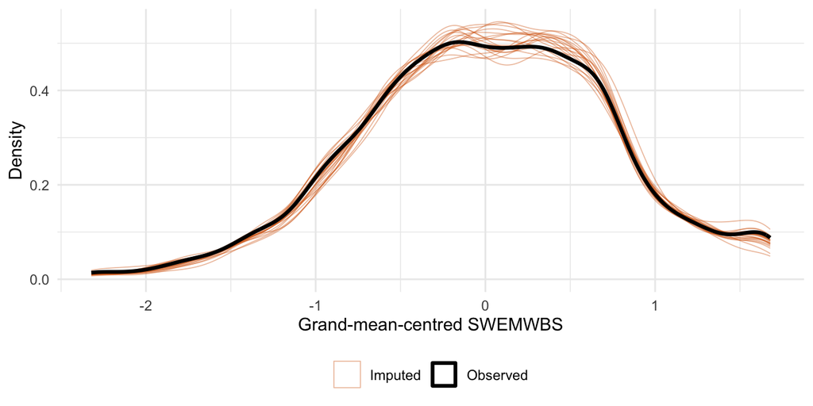

Figure 6: *Multiple-Imputation Distributional Diagnostic.* Observed grand-mean-centred SWEMWBS values (black) against imputed values in 20 of the 100 imputed datasets (thin orange); a subset is shown so the observed curve stays visible, and all 100 behave alike.

The central plausibility check for the imputation model is distributional: imputed wellbeing values should occupy the same range as the observed data and differ from it only in ways explicable by which participants are missing, not by model artefacts. Figure 6 shows the imputed values to be distributionally almost indistinguishable from the observed data: pooled across all 100 imputations, the imputed values had mean 0.013 and SD 0.74 on the centred scale, against an observed mean of 0 (by construction) and SD of 0.75. The imputation model neither compressed the outcome’s variance nor shifted nonresponders’ imputed wellbeing to implausible regions of the scale. Convergence traces and strip plots are produced alongside the cached imputation (`output/qc_imputation/`).

## Predictive Model Comparison

A complementary way to ask whether genre matters is through predictive performance: does adding genre-specific terms to the total-playtime-only M1 baseline improve out-of-sample prediction? We assessed this using approximate leave-one-out cross-validation (LOO-CV) via Pareto-smoothed importance sampling (Vehtari et al., 2017). A positive difference in expected log predictive density (ELPD) relative to M1 indicates that genre terms help.

| Model | dELPD | SE(d) | ELPD | SE | p_loo | LOOIC |
| --- | --- | --- | --- | --- | --- | --- |
| M1: Total playtime only | 0.0 | 0.0 | -4197.5 | 77.9 | 1373.6 | 8395.1 |
| M2: Independent coefficients | -1.0 | 6.1 | -4198.6 | 77.7 | 1353.2 | 8397.1 |
| M3: Hierarchical prior | -7.8 | 4.5 | -4205.3 | 78.1 | 1359.5 | 8410.6 |
| M4: Multi-membership | -8.2 | 3.4 | -4205.7 | 78.3 | 1384.6 | 8411.5 |

Table 9: Leave-one-out cross-validation. Models ordered by expected log predictive density (ELPD); negative dELPD indicates worse out-of-sample prediction than the best-fitting model. SE(d) = standard error of the difference.

## Daily-Timescale Analysis: Design, Results, and Sensitivity Analyses

The Open Play study asked US participants to complete daily surveys for the first 30 study days, including a life-satisfaction item (“I was satisfied with my life today”) answered on a 0–100 slider (Ballou, Földes, Vuorre, et al., 2025), which serves as the outcome. The exposure is console and PC playtime from 4:00 a.m. local time of the response’s waking day up to the survey completion timestamp, which we computed from the same session-level telemetry. Of the 14,814 diary responses from 956 participants in the analytic sample, we analysed the 13,338 responses (90%), from 749 participants, for which telemetry and an analysable same-day window were available. We again split playtime into a within-person and a between-person part, but measured the two parts over different windows. The within-person part is the difference between the day’s same-day playtime and the participant’s own average same-day playtime. The between-person part is the participant’s habitual playtime over a full day, their total telemetry over their observed diary period divided by days, so that differences between participants remain expressed in the same daily-hour units as in the biweekly analysis.

We constructed the SESOI for the slider in the same way as the preregistered one, as a minimally important difference divided by the roughly five hours of daily leisure realistically available (Sturm & Cohen, 2019). No anchor-based minimally important difference exists for a single-item life-satisfaction slider, so we set it at 5 slider points, a deliberately conservative choice. It lies below two available benchmarks, half the within-person SD of the slider (6.1 points) and the preregistered minimally important difference expressed as a share of its scale range (7.5% of 0–100, or 7.5 points), and a smaller minimally important difference makes practical equivalence harder to claim rather than easier. Dividing by five hours gives 1 slider point per hour of daily play. The daily models use the same `brms` default priors as the biweekly models, so `brms` sets the intercept location and the standard-deviation scales from the life-satisfaction outcome: the intercept prior is centred at its median, and the scale of the intercept prior and of every standard-deviation prior, including τ in M3-D, is the larger of 2.5 and its median absolute deviation.

Figure 7 displays the posteriors of the daily models against the ROPE. The multi-membership model’s within-person fixed effect was similar to that of M1-D (M4-D: β = 0.13, 95% CI [-0.31, 0.51]). The SD of the person-specific within-person slopes was 0.7 (95% CI [0.28, 1.01]), with 97.2% of the posterior below the SESOI. Between persons, with habitual play measured in full-day hours, M4-D gave β = -0.4 (95% CI [-1.11, 0.3]).

At the daily level, we described the genre spreads with the same quantities as at the biweekly level, with the daily SESOI of one slider point per hour in place of 0.06, and again without a verdict; the corresponding reference values are 0.51 slider points (1 ÷ 1.96) for genre effects around their average and 0.36 (1 ÷ (1.96 × √2)) for genre pairs. Within persons, the hierarchical prior gave τ<sub>within</sub> = 0.22 (95% CI [0.01, 0.57]), which implied an expected 0.10 of the 14 genres more than one point from the common genre effect and 2.7% of genre pairs more than one point apart. The multi-membership model gave σ<sub>s,within</sub> = 0.49 (95% CI [0.03, 1.3]; an expected 1.2 genres and 16.6% of pairs), and the per-draw SD of M2-D’s 14 independently estimated coefficients, inflated by estimation error as at the biweekly level, was 0.63 (95% CI [0.41, 0.87]; an expected 1.6 genres and 25.6% of pairs). Between persons, τ<sub>between</sub> = 0.9 (95% CI [0.06, 2.13]; an expected 3.5 genres and 36.6% of pairs), σ<sub>s,between</sub> = 0.19 (95% CI [0.01, 0.65]; an expected 0.14 genres and 2.7% of pairs), and M2-D’s between-person raw SD was 2.42 (95% CI [1.49, 3.54]; an expected 9.3 genres and 75.9% of pairs), again inflated by estimation error.

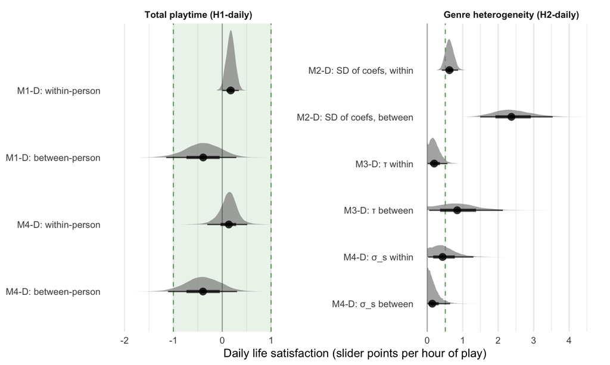

Figure 7: *Exploratory Daily-Timescale Posteriors (Life Satisfaction).* Left: total-playtime effects from the standalone H1 model (M1-D) and the multi-membership model’s fixed effects (M4-D). Right: genre heterogeneity from all three specifications: M2-D (SD across the 14 independently estimated coefficients, computed at each posterior draw), M3-D (hierarchical-prior τ), and M4-D (multi-membership σ_s). Green band: ROPE (±1 slider point per hour) for the total-playtime effects. Dashed line in the right panel: reference value of 0.51 (1 ÷ 1.96), the spread at which 95% of genre effects would lie within one point of the average genre effect; the value for 95% of genre pairs differing by less than one point is 0.36. Both are reference points, not decision criteria (Appendix D, Daily-Timescale Analysis; Appendix F, Spread Descriptors). Thick: 66% credible interval; thin: 95% CI.

Four sensitivity refits accompany the exploratory daily analysis. Allowing first-order autocorrelated residuals with a within-person day trend (estimated AR(1) = 0.32) widened the within-person interval past zero (β = 0.13, 95% CI [-0.02, 0.29]), as did adjusting for window length (β = 0.14, 95% CI [-0.04, 0.31]). Excluding the 8% of Xbox sessions recorded with date-only timestamps, whose start times were floored to midnight and whose minutes were spread uniformly over the recorded day, left the within-person interval above zero (β = 0.18, 95% CI [0.01, 0.35]). The all-responses refit, which retains every diary response and scores unobserved play as zero, gave the same between-person lean as the analysed sample (β = -0.36, 95% CI [-1.02, 0.28]). One qualification applies to the daily genre-level intervals: they inherit the exchangeable-residual assumption that the autocorrelation refit relaxes for the total-playtime model only. Like M3, the daily hierarchical-prior model was estimated in non-centred form; with the same sampler settings as M3 it produced 1 divergent transition, whereas the centred form had produced many in earlier fits, even at the stricter adapt_delta of 0.9995.

## Appendix E: Hypothesis Test Summaries

This appendix tabulates the preregistered joint tests for H2, under the preregistered primary attribution and under full attribution (Deviation D1), and the posterior summaries and convergence diagnostics underlying the hypothesis tests and spread descriptors reported in the Results; the corresponding posterior distributions are shown in Figure 3 (H1) and Figure 4 (H2).

The spread statistic of M2, the SD of its 14 independently estimated coefficients at each posterior draw of the Bayesian fit, was not preregistered. Within persons, it averaged 0.032 (95% CI: [0.02, 0.047]; Figure 4, top row). It implied that 7% of genres (95% CI [0.3%, 20.3%]) lay more than 0.06 from the average genre effect, an expected 0.98 of the 14, and that 18.5% of genre pairs (95% CI [3.7%, 36.8%]) differed by more than 0.06. Between persons, it averaged 0.082 (95% CI: [0.048, 0.129]), which implied that 44.3% of genres (95% CI [21%, 64.1%]) lay more than 0.06 from the average genre effect, an expected 6.2 of the 14, and that 58.4% of genre pairs (95% CI [37.5%, 74.1%]) differed by more than 0.06, and its upper credible bound was more than twice that of M3’s τ<sub>between</sub>. The means of the 14 M2 coefficients were 0.007 (95% CI: [-0.003, 0.018]) within persons and -0.013 (95% CI: [-0.039, 0.014]) between persons, against M3’s common genre effects γ<sub>W</sub> and γ<sub>B</sub> in the Results.

The share of the genre-effect distribution outside the ROPE was 7.9% under M2 (95% CI: [0.4%, 22.5%]) and 16.3% under M4 (95% CI: [0%, 54%]) within persons, and 45.4% under M2 (95% CI: [22.2%, 65%]) and 4.1% under M4 (95% CI: [0%, 26.1%]) between persons. The M2 shares were inflated by the wide intervals of rarely played genres, and the M4 shares reflected uncertainty in both the spread and the overall playtime slope.

| Hyp. | Model | Status | Parameter | Estimate | 95% CI | % in ROPE | Genres > 0.06 (of 14) | Pairs > 0.06 (%) | Outside ROPE (%) | R-hat | Div. |
| --- | --- | --- | --- | --- | --- | --- | --- | --- | --- | --- | --- |
| H1: Total playtime, dose–response | H1: Total playtime, dose–response | H1: Total playtime, dose–response | H1: Total playtime, dose–response | H1: Total playtime, dose–response | H1: Total playtime, dose–response | H1: Total playtime, dose–response | H1: Total playtime, dose–response | H1: Total playtime, dose–response | H1: Total playtime, dose–response | H1: Total playtime, dose–response | H1: Total playtime, dose–response |
| H1a | M1 | Preregistered | Within-person slope | 0.004 | [-0.007, 0.015] | >99.9 | – | – | – | 1.006 | 0 |
| H1b | M1 | Preregistered | Between-person slope | -0.015 | [-0.034, 0.003] | >99.9 | – | – | – | 1.006 | 0 |
| H2a: Genre differences, within-person | H2a: Genre differences, within-person | H2a: Genre differences, within-person | H2a: Genre differences, within-person | H2a: Genre differences, within-person | H2a: Genre differences, within-person | H2a: Genre differences, within-person | H2a: Genre differences, within-person | H2a: Genre differences, within-person | H2a: Genre differences, within-person | H2a: Genre differences, within-person | H2a: Genre differences, within-person |
| H2a | M2 (ML), primary | Preregistered | Joint Wald test: χ²(13) = 16.6, p = 0.216 | – | – | – | – | – | – | – | – |
| H2a | M2 (ML), full | Preregistered (D1) | Joint Wald test: χ²(13) = 24.8, p = 0.025 | – | – | – | – | – | – | – | – |
| H2a | M2 | Preregistered (D1) | SD of genre coefficients | 0.032 | [0.020, 0.047] | – | 0.98 | 18.5 | 7.9 | 1.004 | 0 |
| H2a | M3 | Exploratory | τ (hierarchical-prior scale) | 0.016 | [0.005, 0.031] | – | 0.08 | 2.6 | 0.7 | 1.004 | 0 |
| H2a | M4 | Exploratory | σ_s (random-slope SD) | 0.038 | [0.004, 0.091] | – | 2.0 | 24.8 | 16.3 | 1.003 | 0 |
| H2b: Genre differences, between-person | H2b: Genre differences, between-person | H2b: Genre differences, between-person | H2b: Genre differences, between-person | H2b: Genre differences, between-person | H2b: Genre differences, between-person | H2b: Genre differences, between-person | H2b: Genre differences, between-person | H2b: Genre differences, between-person | H2b: Genre differences, between-person | H2b: Genre differences, between-person | H2b: Genre differences, between-person |
| H2b | M2 (ML), primary | Preregistered | Joint Wald test: χ²(13) = 15.4, p = 0.284 | – | – | – | – | – | – | – | – |
| H2b | M2 (ML), full | Preregistered (D1) | Joint Wald test: χ²(13) = 14.9, p = 0.315 | – | – | – | – | – | – | – | – |
| H2b | M2 | Preregistered (D1) | SD of genre coefficients | 0.082 | [0.048, 0.129] | – | 6.2 | 58.4 | 45.4 | 1.004 | 0 |
| H2b | M3 | Exploratory | τ (hierarchical-prior scale) | 0.019 | [0.001, 0.054] | – | 0.48 | 7.9 | 4.2 | 1.004 | 0 |
| H2b | M4 | Exploratory | σ_s (random-slope SD) | 0.019 | [0.002, 0.047] | – | 0.35 | 6.9 | 4.1 | 1.003 | 0 |

All estimates are in SWEMWBS item-mean points per hour/day. ROPE = region of practical equivalence, −0.06 to +0.06, applied to the H1 slopes, which are the fixed effects of the standalone total-playtime model (M1), and, in the Outside ROPE column, to the H2 genre-effect distributions. H2 is answered by the preregistered joint Wald tests of equal genre coefficients, run on the maximum-likelihood fit of M2 with a random intercept (M2 (ML); Results), under the preregistered primary-genre attribution (primary), under which neither test rejected equality, and under full attribution (full; Deviation D1). The three spread statistics describe genre-to-genre variation in exposure effects without a verdict: M2 reports the SD across its 14 independently estimated coefficients at each posterior draw (inflated by their estimation error), M3 the hierarchical-prior scale τ, and M4 σ_s, the SD of genre random-slope deviations under multi-membership weighting. Genres > 0.06: expected number of the 14 genres whose effect lies more than 0.06 from the average genre effect; Pairs > 0.06: share of genre pairs whose effects differ by more than 0.06; Outside ROPE: share of the genre-effect distribution, centred on the model's average genre effect, that lies outside ±0.06; all three are posterior means of per-draw quantities under normally distributed genre effects (Methods; Appendix F). R-hat is the maximum across all parameters of the fitted model; Div. = number of divergent transitions. Status follows the model and the attribution: M1 and M2 are the preregistered models, under Bayesian estimation (Deviation D3), with genre exposures by full attribution (D1) except in the primary rows, and M3 and M4 are exploratory; the spread statistics and their descriptors, including those of M2, were not preregistered.

Table 10: Hypothesis tests at the biweekly timescale, labelled by preregistration status: for H1, posterior estimates, 95% credible intervals and posterior mass inside the ROPE; for H2, the preregistered joint tests under primary and under full attribution and the descriptive spread statistics with their three descriptors; and convergence diagnostics.

| Hypothesis | Model | Parameter | Estimate | 95% CI | % in ROPE | Genres > 1 (of 14) | Pairs > 1 (%) | R-hat | Div. |
| --- | --- | --- | --- | --- | --- | --- | --- | --- | --- |
| H1a-daily | M1-D | Within-person slope | 0.17 | [0.00, 0.34] | >99.9 | – | – | 1.012 | 0 |
| H1a-daily | M4-D | Within-person slope (fixed effect) | 0.13 | [-0.31, 0.51] | 99.9 | – | – | 1.004 | 0 |
| H1b-daily | M1-D | Between-person slope | -0.40 | [-1.15, 0.29] | 94.7 | – | – | 1.012 | 0 |
| H1b-daily | M4-D | Between-person slope (fixed effect) | -0.40 | [-1.11, 0.30] | 95.2 | – | – | 1.004 | 0 |
| H2a-daily | M2-D | SD of genre coefficients | 0.63 | [0.41, 0.87] | – | 1.6 | 25.6 | 1.015 | 0 |
| H2a-daily | M3-D | τ (hierarchical-prior scale) | 0.22 | [0.01, 0.57] | – | 0.10 | 2.7 | 1.007 | 1 |
| H2a-daily | M4-D | σ_s (random-slope SD) | 0.49 | [0.03, 1.30] | – | 1.2 | 16.6 | 1.004 | 0 |
| H2b-daily | M2-D | SD of genre coefficients | 2.42 | [1.49, 3.54] | – | 9.3 | 75.9 | 1.015 | 0 |
| H2b-daily | M3-D | τ (hierarchical-prior scale) | 0.90 | [0.06, 2.13] | – | 3.5 | 36.6 | 1.007 | 1 |
| H2b-daily | M4-D | σ_s (random-slope SD) | 0.19 | [0.01, 0.65] | – | 0.14 | 2.7 | 1.004 | 0 |

Table 11: Exploratory daily-timescale hypothesis tests (see Daily Timescale in Results and Appendix D): posterior estimates, 95% credible intervals, posterior mass inside the ROPE for the total-playtime slopes (±1 slider point per hour; within-person rows are per hour of same-day play, between-person rows per hour of habitual daily play), descriptors of the genre spreads without a verdict (Genres > 1: expected number of the 14 genres more than one point from the average genre effect; Pairs > 1: share of genre pairs more than one point apart; posterior means, see Appendix F), and convergence diagnostics. M2-D rows are the SD across the 14 independently estimated genre coefficients, computed at each posterior draw, and include estimation error.

## Appendix F: Model Specifications and Priors

This appendix gives the equations and priors of the four biweekly models; the Methods describe what each model estimates and why we fitted it (Preregistered Models and Exploratory Models). The daily refits M1-D to M4-D use the same specifications with the daily outcome and exposures; `brms` then sets the intercept location and the standard-deviation scales from the life-satisfaction outcome (Appendix D, Daily-Timescale Analysis). The appendix closes with the time-use evidence behind the SESOI and the formulas of the spread descriptors.

## M1 specification: Total Playtime

M1, the preregistered model for H1, regresses SWEMWBS on the within-person and between-person parts of total playtime, with a random intercept and a random within-person playtime slope for each participant.

$$\begin{aligned}
\text{SWEMWBS}_{ij} &\sim \text{Normal}(\mu_{ij}, \sigma) \\
\mu_{ij} &= (\alpha + u_{0j}) + (\beta_W + u_{1j})\, \text{Time}_{\text{within},ij} + \beta_B\, \text{Time}_{\text{between},j} \\
\begin{pmatrix} u_{0j} \\ u_{1j} \end{pmatrix} &\sim \text{Normal}\left(\mathbf{0}, \boldsymbol{\Sigma}_u\right), \quad \boldsymbol{\Sigma}_u = \begin{pmatrix} \sigma_{u0}^2 & \rho_u\, \sigma_{u0}\, \sigma_{u1} \\ \rho_u\, \sigma_{u0}\, \sigma_{u1} & \sigma_{u1}^2 \end{pmatrix} \\
\alpha &\sim \text{Student-}t(3, \tilde{y}, 2.5) \\
\beta_W, \beta_B &\propto 1
\end{aligned}$$

In this and the following equations, $i$ indexes biweekly survey waves, $j$ participants, and, from M2 onwards, $g$ genres. $\text{Time}_{\text{within},ij}$ is participant $j$’s average daily playtime on Nintendo, Xbox, and Steam (hours per day over the 14 days before wave $i$’s scheduled survey) minus that participant’s mean across all of their survey waves, and $\text{Time}_{\text{between},j}$ is that mean. $\alpha$, $\beta_W$, and $\beta_B$ are the population intercept and slopes; $u_{0j}$ and $u_{1j}$ are participant $j$’s deviations from $\alpha$ and $\beta_W$, so that participant $j$’s own intercept is $\alpha + u_{0j}$ and own within-person slope is $\beta_W + u_{1j}$; $\boldsymbol{\Sigma}_u$ is the covariance matrix of these deviations, with standard deviations $\sigma_{u0}$ and $\sigma_{u1}$ and correlation $\rho_u$; $\sigma$ is the residual standard deviation; $\tilde{y}$ is the sample median of SWEMWBS; and $\propto 1$ denotes an improper flat prior.

## M2 specification: Independent Genre Coefficients

M2, the preregistered model for H2, replaces total playtime with the within-person and between-person exposures to each of the 14 genres, estimates their coefficients independently, and has a random intercept only.

$$\begin{aligned}
\text{SWEMWBS}_{ij} &\sim \text{Normal}(\mu_{ij}, \sigma) \\
\mu_{ij} &= (\alpha + u_{0j}) + \sum_{g=1}^{G}\bigl(\beta_{W,g}\, \text{Time}_{\text{within},g,ij} + \beta_{B,g}\, \text{Time}_{\text{between},g,j}\bigr) \\
u_{0j} &\sim \text{Normal}(0, \sigma_{u0}) \\
\alpha &\sim \text{Student-}t(3, \tilde{y}, 2.5) \\
\beta_{W,g}, \beta_{B,g} &\propto 1
\end{aligned}$$

Here $g$ indexes the $G$ = 14 genres. $\text{Time}_{\text{within},g,ij}$ and $\text{Time}_{\text{between},g,j}$ split participant $j$’s exposure to genre $g$, the average daily hours spent on games carrying that genre label (a multi-genre game’s full playtime counts towards each of its labels), in the same way as total playtime; $\beta_{W,g}$ and $\beta_{B,g}$ are their coefficients; and $\sigma_{u0}$ is the standard deviation of the participant intercept deviations $u_{0j}$.

## M3 specification: Hierarchical Prior

M3, an exploratory model, keeps M2’s predictors and random intercept but draws the within-person and the between-person genre coefficients from two normal distributions whose centres and standard deviations it estimates.

$$\begin{aligned}
\text{SWEMWBS}_{ij} &\sim \text{Normal}(\mu_{ij}, \sigma) \\
\mu_{ij} &= (\alpha + u_{0j}) + \sum_{g=1}^{G}\bigl(\beta_{W,g}\, \text{Time}_{\text{within},g,ij} + \beta_{B,g}\, \text{Time}_{\text{between},g,j}\bigr) \\
u_{0j} &\sim \text{Normal}(0, \sigma_{u0}) \\
\beta_{W,g} &\sim \text{Normal}(\gamma_W, \tau_{\text{within}}) \\
\beta_{B,g} &\sim \text{Normal}(\gamma_B, \tau_{\text{between}}) \\
\gamma_W, \gamma_B &\propto 1 \\
\tau_{\text{within}}, \tau_{\text{between}} &\sim \text{Half-Student-}t(3, 0, 2.5) \\
\alpha &\sim \text{Student-}t(3, \tilde{y}, 2.5)
\end{aligned}$$

The symbols are as in M2. $\gamma_W$ and $\gamma_B$ are the centres and $\tau_{\text{within}}$ and $\tau_{\text{between}}$ the standard deviations of the distributions from which the within-person and between-person genre coefficients are drawn. $\gamma_W$ and $\gamma_B$ receive the same improper flat prior as the slopes in M1 and M2, and $\tau_{\text{within}}$ and $\tau_{\text{between}}$ describe the size of the genre differences in the within-person (H2a) and between-person (H2b) dimensions. Because the centred form of this model, in which the sampler draws each genre coefficient directly from its normal distribution, produced dozens of divergent transitions in earlier fits, we estimate it in the equivalent non-centred form $\beta_{W,g} = \gamma_W + \tau_{\text{within}}\, z_{W,g}$ and $\beta_{B,g} = \gamma_B + \tau_{\text{between}}\, z_{B,g}$, with $z_{W,g}, z_{B,g} \sim \text{Normal}(0, 1)$. In `brms` this is a model with slopes $\gamma_W$ and $\gamma_B$ on the summed genre exposures plus two genre-level random terms weighted by the genre exposures (the multi-membership construction that M4 also uses); it changes neither the likelihood nor the priors on $\gamma$ and $\tau$. An earlier version of M3 fixed the centres at zero; following co-author review, and after the results of that version were known, we estimate them instead, so that τ measures the spread around the common genre effect rather than around zero. Because sampling near τ = 0 is numerically difficult, we also use conservative sampler settings, and we report divergence counts and R-hat diagnostics for every model alongside the results.

## M4 specification: Multi-Membership

M4, an exploratory model, keeps M1’s total-playtime terms and participant effects and lets the genre composition of each wave adjust the within-person and between-person playtime slopes. Formally, this is a multi-membership structure: every wave belongs to all 14 genres, and only the membership weights vary, each equal to the genre’s share of the wave’s summed genre exposure.

$$\begin{aligned}
\text{SWEMWBS}_{ij} &\sim \text{Normal}(\mu_{ij}, \sigma) \\
\mu_{ij} &= (\alpha + u_{0j}) + \Bigl(\beta_W + u_{1j} + \sum_{g=1}^{G} w_{g,ij}\, s_{W,g}\Bigr) \text{Time}_{\text{within},ij} \\
&\quad + \Bigl(\beta_B + \sum_{g=1}^{G} w_{g,ij}\, s_{B,g}\Bigr) \text{Time}_{\text{between},j} \\
\begin{pmatrix} u_{0j} \\ u_{1j} \end{pmatrix} &\sim \text{Normal}\left(\mathbf{0}, \boldsymbol{\Sigma}_u\right) \\
\begin{pmatrix} s_{W,g} \\ s_{B,g} \end{pmatrix} &\sim \text{Normal}\left(\mathbf{0}, \boldsymbol{\Sigma}_s\right) \\
\boldsymbol{\Sigma}_s &= \begin{pmatrix} \sigma_{s,W}^2 & \rho_s\, \sigma_{s,W}\, \sigma_{s,B} \\ \rho_s\, \sigma_{s,W}\, \sigma_{s,B} & \sigma_{s,B}^2 \end{pmatrix} \\
\alpha &\sim \text{Student-}t(3, \tilde{y}, 2.5) \\
\beta_W, \beta_B &\propto 1 \\
\sigma_{s,\text{within}}, \sigma_{s,\text{between}} &\sim \text{Half-Student-}t(3, 0, 2.5) \\
\begin{pmatrix} 1 & \rho_s \\ \rho_s & 1 \end{pmatrix} &\sim \text{LKJ}(1)
\end{aligned}$$

The participant terms are as in M1. $w_{g,ij}$ is genre $g$’s exposure hours in participant $j$’s wave $i$ divided by the summed exposure hours of all $G$ genres in that wave, so a wave’s weights sum to one; because exposure uses full attribution, a game with two genre labels adds its hours to both. Waves without genre-labelled play, most of them without any recorded play, receive $w_{g,ij} = 1/G$. $s_{W,g}$ and $s_{B,g}$ are genre $g$’s adjustments to the within-person and between-person playtime slopes; because the weights describe each wave’s genre mix, the between-person adjustment follows the wave’s mix rather than the participant’s habitual mix. The two adjustments are drawn jointly, with standard deviations $\sigma_{s,\text{within}}$ and $\sigma_{s,\text{between}}$ (written $\sigma_{s,W}$ and $\sigma_{s,B}$ in the equation) and correlation $\rho_s$; the LKJ(1) prior on their 2 × 2 correlation matrix is uniform over $\rho_s$.

Because this use of multi-membership is unconventional, we validated the specification by parameter recovery. The simulation fits the manuscript’s own M4 code, read from this document at run time, to 20 synthetic datasets of 200 participants over six waves with known within-person and between-person genre heterogeneity. The 95% credible intervals covered each of the ten true values in at least 19 of the 20 replications, with no divergent transitions. At this sample size, a fraction of the real one, the genre-level standard deviations were estimated with upward bias (posterior means of 0.12 within and 0.06 between persons for true values of 0.04), and the correlation between the within-person and between-person adjustments was weakly identified (true value 0.3, averaged 95% CI [-0.93, 0.93]), so σ<sub>s</sub> should be read with its interval rather than its point estimate (simulation report in the supplementary materials).

## Priors

All models use the `brms` default priors (Bürkner, 2017). The slopes have improper flat priors, so that the data alone determine their estimates, which are directly comparable with the preregistered maximum-likelihood analysis; the exception is M3, whose genre coefficients receive the hierarchical prior that defines the model. `brms` places the intercept prior on the intercept with all predictors at their sample means, that is, on expected wellbeing at average playtime (for M3, at the mean summed genre exposure), from which `brms` recovers $\alpha$ after sampling; this prior is Student-$t$(3, 3.3, 2.5), centred at the sample median of SWEMWBS. The residual standard deviation $\sigma$ and every other standard deviation, including the participant-level standard deviations and the genre-level spreads τ (M3) and σ<sub>s</sub> (M4), have half-Student-$t$(3, 0, 2.5) priors; their scale is the larger of 2.5 and the median absolute deviation of the outcome, which for SWEMWBS gives 2.5. Both τ and σ<sub>s</sub> are standard deviations of `brms` group-level terms (for τ, in the non-centred form of M3 described above), so `brms` assigns this prior to them by default. Each correlation matrix has an LKJ(1) prior, which for a 2 × 2 matrix is uniform over the single correlation. An earlier version used weakly informative Student-$t$ priors on the slopes and intercept, a Half-Normal(0, 0.1) hyperprior on τ and a Normal(0, 0.3) prior on σ<sub>s</sub>; following co-author review, and after those results were known, we adopted the defaults so that no analyst-chosen scale enters the models.

## Time-Use Evidence for the SESOI

The preregistered SESOI divides the minimally important difference of 0.3 points by the approximately 5 hours of daily leisure time that US adults average (Sturm & Cohen, 2019). More recent diaries put the figure lower for our age range. Americans aged 23 to 38 averaged about 4.3 hours a day in 2019 (Freeman, 2022), and 3.8 to 4.7 hours by age band between 20 and 44 in 2024 (U.S. Bureau of Labor Statistics, 2025); UK adults aged 18 to 44 averaged between 4.3 and 5.2 hours in 2014, depending on sex and age band (summing the leisure components in Table 3 of García Román & Gracia (2022)). Five hours is therefore an upper bound, and the preregistered SESOI the stricter of the two choices.

## Spread Descriptors

For the spread *s* defined in the Methods, and treating the genre effects as normally distributed around their average, the share of genres whose effect lies more than 0.06 from the average genre effect is $2[1 - \Phi(0.06/s)]$, where $\Phi$ is the standard normal distribution function, and multiplying it by 14 gives the expected number of our genres that this share implies. The share of genre pairs whose effects differ by more than 0.06 is $2[1 - \Phi(0.06/(\sqrt{2}\,s))]$, because the difference between two genre effects drawn from the same distribution has standard deviation $\sqrt{2}\,s$. The share outside the ROPE is that of a normal distribution with the model’s average genre effect as its mean and *s* as its standard deviation (Vuorre, Kay, et al., 2024). Unlike the first two, this share depends on the average genre effect as well as on the spread, so it describes whether the associations are practically null in every genre rather than whether genres differ. We do not turn these quantities into a verdict, because we can translate the SESOI into a threshold for differences between genres in more than one defensible way, and the translations set different thresholds: for 95% of genre effects to lie within 0.06 of the average, the spread must be below 0.031 (0.06 ÷ 1.96), whereas for 95% of genre pairs to differ by less than 0.06, it must be below 0.022 (0.06 ÷ (1.96 × √2)).